# ANCOVA test for textual (engajamento no textual)

Geiser C. Challco geiser@alumni.usp.br

- Descriptive Statistics of Initial Data
- Checking of Assumptions
  - Assumption: Normality distribution of data
  - Assumption: Homogeneity of data distribution
- Computation of ANCOVA test and Pairwise Comparison
  - ANCOVA tests for one factor
  - ANCOVA tests for two factors
  - ANCOVA tests for grupo=“WordGen”
  - Pairwise comparisons for one factor
    - factor: **grupo**
    - factor: **genero**
    - factor: **idade**
    - factor: **zona.participante**
    - factor: **escola**
    - factor: **zona.escola**
  - Pairwise comparisons for two factors
    - factores: **grupo:genero**
    - factores: **grupo:idade**
    - factores: **grupo:zona.participante**
    - factores: **grupo:escola**
    - factores: **grupo:zona.escola**
  - Pairwise comparisons for grupo=“Experimental”
    - factores: **grupo=“Experimental”:monitor**
    - factores: **grupo=“Experimental”:monitor.genero**
    - factores: **grupo=“Experimental”:monitor.area**
    - factores: **grupo=“Experimental”:monitor.formacao**
    - factores: **grupo=“Experimental”:monitor.experiencia**

**NOTE**

- Teste ANCOVA para determinar se houve diferenças significativas em referência ao engajamento no textual (medido como estado de fluxo).
- ANCOVA test to determine whether there were significant differences in reference to engagement in textual (measured as flow state).

# Descriptive Statistics of Initial Data

| grupo | genero | idade | zona.participante | escola | zona.escola | variable | n | mean | median | min | max | sd | se | ci | iqr |
| --- | --- | --- | --- | --- | --- | --- | --- | --- | --- | --- | --- | --- | --- | --- | --- |
| Controle | F |  |  |  |  | fss.textual | 59 | 3.542 | 3.556 | 2.222 | 4.778 | 0.605 | 0.079 | 0.158 | 0.722 |
| Controle | M |  |  |  |  | fss.textual | 62 | 3.439 | 3.444 | 2.444 | 5.000 | 0.551 | 0.070 | 0.140 | 0.750 |
| WordGen | F |  |  |  |  | fss.textual | 53 | 3.732 | 3.778 | 2.222 | 5.000 | 0.548 | 0.075 | 0.151 | 0.667 |
| WordGen | M |  |  |  |  | fss.textual | 62 | 3.379 | 3.333 | 1.750 | 4.667 | 0.610 | 0.078 | 0.155 | 0.750 |
| Controle | F |  |  |  |  | dfs.textual | 59 | 3.536 | 3.556 | 2.222 | 4.556 | 0.593 | 0.077 | 0.155 | 0.889 |
| Controle | M |  |  |  |  | dfs.textual | 62 | 3.490 | 3.444 | 2.000 | 4.667 | 0.537 | 0.068 | 0.136 | 0.778 |
| WordGen | F |  |  |  |  | dfs.textual | 53 | 3.601 | 3.556 | 2.333 | 4.714 | 0.537 | 0.074 | 0.148 | 0.667 |
| WordGen | M |  |  |  |  | dfs.textual | 62 | 3.428 | 3.333 | 2.444 | 4.778 | 0.566 | 0.072 | 0.144 | 0.778 |
| Controle |  | 10y |  |  |  | fss.textual | 23 | 3.580 | 3.556 | 2.222 | 4.778 | 0.644 | 0.134 | 0.279 | 1.000 |
| Controle |  | 11y |  |  |  | fss.textual | 64 | 3.555 | 3.556 | 2.222 | 5.000 | 0.581 | 0.073 | 0.145 | 0.806 |
| Controle |  | 12y |  |  |  | fss.textual | 18 | 3.351 | 3.222 | 2.667 | 4.556 | 0.578 | 0.136 | 0.287 | 0.788 |
| Controle |  | 13y |  |  |  | fss.textual | 7 | 3.190 | 3.222 | 2.778 | 3.444 | 0.210 | 0.079 | 0.194 | 0.111 |
| Controle |  | 14y |  |  |  | fss.textual | 1 | 3.556 | 3.556 | 3.556 | 3.556 |  |  |  | 0.000 |
| Controle |  | 15y |  |  |  | fss.textual | 1 | 2.889 | 2.889 | 2.889 | 2.889 |  |  |  | 0.000 |
| Controle |  | 16y |  |  |  | fss.textual | 1 | 2.889 | 2.889 | 2.889 | 2.889 |  |  |  | 0.000 |
| Controle |  |  |  |  |  | fss.textual | 6 | 3.389 | 3.444 | 2.667 | 4.111 | 0.543 | 0.222 | 0.570 | 0.722 |
| WordGen |  | 10y |  |  |  | fss.textual | 22 | 3.481 | 3.444 | 2.667 | 4.444 | 0.505 | 0.108 | 0.224 | 0.639 |
| WordGen |  | 11y |  |  |  | fss.textual | 70 | 3.631 | 3.556 | 2.000 | 5.000 | 0.598 | 0.071 | 0.143 | 0.667 |
| WordGen |  | 12y |  |  |  | fss.textual | 14 | 3.548 | 3.667 | 2.556 | 4.333 | 0.582 | 0.156 | 0.336 | 0.889 |
| WordGen |  | 13y |  |  |  | fss.textual | 6 | 2.736 | 2.889 | 1.750 | 3.333 | 0.544 | 0.222 | 0.571 | 0.333 |
| WordGen |  | 14y |  |  |  | fss.textual | 1 | 4.444 | 4.444 | 4.444 | 4.444 |  |  |  | 0.000 |
| WordGen |  |  |  |  |  | fss.textual | 2 | 3.000 | 3.000 | 2.889 | 3.111 | 0.157 | 0.111 | 1.412 | 0.111 |
| Controle |  | 10y |  |  |  | dfs.textual | 23 | 3.572 | 3.778 | 2.444 | 4.444 | 0.546 | 0.114 | 0.236 | 0.833 |
| Controle |  | 11y |  |  |  | dfs.textual | 64 | 3.599 | 3.667 | 2.222 | 4.667 | 0.557 | 0.070 | 0.139 | 0.778 |
| Controle |  | 12y |  |  |  | dfs.textual | 18 | 3.367 | 3.292 | 2.667 | 4.556 | 0.513 | 0.121 | 0.255 | 0.806 |
| Controle |  | 13y |  |  |  | dfs.textual | 7 | 3.450 | 3.444 | 2.556 | 4.375 | 0.574 | 0.217 | 0.531 | 0.444 |
| Controle |  | 14y |  |  |  | dfs.textual | 1 | 3.778 | 3.778 | 3.778 | 3.778 |  |  |  | 0.000 |
| Controle |  | 15y |  |  |  | dfs.textual | 1 | 2.000 | 2.000 | 2.000 | 2.000 |  |  |  | 0.000 |
| Controle |  | 16y |  |  |  | dfs.textual | 1 | 3.444 | 3.444 | 3.444 | 3.444 |  |  |  | 0.000 |
| Controle |  |  |  |  |  | dfs.textual | 6 | 3.093 | 2.944 | 2.667 | 3.889 | 0.463 | 0.189 | 0.486 | 0.500 |
| WordGen |  | 10y |  |  |  | dfs.textual | 22 | 3.393 | 3.278 | 2.333 | 4.778 | 0.665 | 0.142 | 0.295 | 0.861 |
| WordGen |  | 11y |  |  |  | dfs.textual | 70 | 3.582 | 3.563 | 2.444 | 4.714 | 0.523 | 0.063 | 0.125 | 0.667 |
| WordGen |  | 12y |  |  |  | dfs.textual | 14 | 3.508 | 3.556 | 2.444 | 4.333 | 0.603 | 0.161 | 0.348 | 1.083 |
| WordGen |  | 13y |  |  |  | dfs.textual | 6 | 3.130 | 3.056 | 2.778 | 3.556 | 0.310 | 0.126 | 0.325 | 0.444 |
| WordGen |  | 14y |  |  |  | dfs.textual | 1 | 3.222 | 3.222 | 3.222 | 3.222 |  |  |  | 0.000 |
| WordGen |  |  |  |  |  | dfs.textual | 2 | 3.444 | 3.444 | 3.000 | 3.889 | 0.629 | 0.444 | 5.647 | 0.444 |
| Controle |  |  | Urbana |  |  | fss.textual | 53 | 3.553 | 3.556 | 2.222 | 5.000 | 0.589 | 0.081 | 0.162 | 0.667 |
| Controle |  |  | Rural |  |  | fss.textual | 42 | 3.370 | 3.333 | 2.444 | 4.778 | 0.576 | 0.089 | 0.179 | 0.750 |
| Controle |  |  |  |  |  | fss.textual | 26 | 3.551 | 3.611 | 2.222 | 4.556 | 0.548 | 0.108 | 0.221 | 0.583 |
| WordGen |  |  | Urbana |  |  | fss.textual | 43 | 3.548 | 3.556 | 1.750 | 4.778 | 0.549 | 0.084 | 0.169 | 0.611 |
| WordGen |  |  | Rural |  |  | fss.textual | 47 | 3.557 | 3.444 | 2.000 | 5.000 | 0.656 | 0.096 | 0.193 | 1.167 |
| WordGen |  |  |  |  |  | fss.textual | 25 | 3.502 | 3.556 | 2.222 | 4.556 | 0.625 | 0.125 | 0.258 | 0.778 |
| Controle |  |  | Urbana |  |  | dfs.textual | 53 | 3.535 | 3.500 | 2.000 | 4.667 | 0.596 | 0.082 | 0.164 | 0.889 |
| Controle |  |  | Rural |  |  | dfs.textual | 42 | 3.514 | 3.500 | 2.444 | 4.556 | 0.573 | 0.088 | 0.179 | 0.889 |
| Controle |  |  |  |  |  | dfs.textual | 26 | 3.464 | 3.444 | 2.444 | 4.111 | 0.492 | 0.096 | 0.199 | 0.750 |
| WordGen |  |  | Urbana |  |  | dfs.textual | 43 | 3.432 | 3.444 | 2.333 | 4.714 | 0.585 | 0.089 | 0.180 | 1.000 |
| WordGen |  |  | Rural |  |  | dfs.textual | 47 | 3.515 | 3.444 | 2.444 | 4.778 | 0.596 | 0.087 | 0.175 | 1.000 |
| WordGen |  |  |  |  |  | dfs.textual | 25 | 3.623 | 3.667 | 2.778 | 4.444 | 0.414 | 0.083 | 0.171 | 0.444 |
| Controle |  |  |  | E1 |  | fss.textual | 11 | 3.465 | 3.444 | 2.889 | 4.444 | 0.516 | 0.156 | 0.347 | 0.556 |
| Controle |  |  |  | E2 |  | fss.textual | 23 | 3.497 | 3.500 | 2.222 | 5.000 | 0.731 | 0.152 | 0.316 | 1.000 |
| Controle |  |  |  | E3 |  | fss.textual | 14 | 3.348 | 3.333 | 2.556 | 4.222 | 0.410 | 0.110 | 0.237 | 0.306 |
| Controle |  |  |  | E4 |  | fss.textual | 16 | 3.331 | 3.333 | 2.444 | 4.111 | 0.513 | 0.128 | 0.273 | 0.552 |
| Controle |  |  |  | E5 |  | fss.textual | 46 | 3.556 | 3.556 | 2.556 | 4.778 | 0.587 | 0.087 | 0.174 | 1.083 |
| Controle |  |  |  | E6 |  | fss.textual | 11 | 3.626 | 3.667 | 2.222 | 4.222 | 0.536 | 0.162 | 0.360 | 0.389 |
| WordGen |  |  |  | E1 |  | fss.textual | 10 | 4.003 | 3.889 | 3.333 | 5.000 | 0.596 | 0.189 | 0.426 | 0.896 |
| WordGen |  |  |  | E2 |  | fss.textual | 24 | 3.341 | 3.444 | 1.750 | 4.111 | 0.534 | 0.109 | 0.225 | 0.528 |
| WordGen |  |  |  | E3 |  | fss.textual | 14 | 3.440 | 3.389 | 2.000 | 4.333 | 0.690 | 0.184 | 0.398 | 1.111 |
| WordGen |  |  |  | E4 |  | fss.textual | 9 | 3.691 | 3.778 | 2.778 | 4.444 | 0.605 | 0.202 | 0.465 | 1.000 |
| WordGen |  |  |  | E5 |  | fss.textual | 47 | 3.528 | 3.556 | 2.222 | 4.667 | 0.580 | 0.085 | 0.170 | 0.778 |
| WordGen |  |  |  | E6 |  | fss.textual | 11 | 3.626 | 3.667 | 2.556 | 4.556 | 0.631 | 0.190 | 0.424 | 0.778 |
| Controle |  |  |  | E1 |  | dfs.textual | 11 | 3.278 | 3.444 | 2.000 | 4.111 | 0.625 | 0.188 | 0.420 | 0.750 |
| Controle |  |  |  | E2 |  | dfs.textual | 23 | 3.536 | 3.556 | 2.667 | 4.667 | 0.568 | 0.118 | 0.246 | 0.889 |
| Controle |  |  |  | E3 |  | dfs.textual | 14 | 3.588 | 3.667 | 2.778 | 4.444 | 0.544 | 0.145 | 0.314 | 0.740 |
| Controle |  |  |  | E4 |  | dfs.textual | 16 | 3.512 | 3.444 | 2.778 | 4.375 | 0.386 | 0.096 | 0.205 | 0.472 |
| Controle |  |  |  | E5 |  | dfs.textual | 46 | 3.492 | 3.472 | 2.222 | 4.556 | 0.644 | 0.095 | 0.191 | 1.083 |
| Controle |  |  |  | E6 |  | dfs.textual | 11 | 3.686 | 3.875 | 3.000 | 4.111 | 0.350 | 0.106 | 0.235 | 0.500 |
| WordGen |  |  |  | E1 |  | dfs.textual | 10 | 3.510 | 3.500 | 2.750 | 4.222 | 0.470 | 0.149 | 0.336 | 0.556 |
| WordGen |  |  |  | E2 |  | dfs.textual | 24 | 3.426 | 3.444 | 2.444 | 4.222 | 0.471 | 0.096 | 0.199 | 0.639 |
| WordGen |  |  |  | E3 |  | dfs.textual | 14 | 3.531 | 3.667 | 2.444 | 4.556 | 0.730 | 0.195 | 0.422 | 1.344 |
| WordGen |  |  |  | E4 |  | dfs.textual | 9 | 3.704 | 3.444 | 3.000 | 4.444 | 0.611 | 0.204 | 0.470 | 1.111 |
| WordGen |  |  |  | E5 |  | dfs.textual | 47 | 3.488 | 3.444 | 2.333 | 4.778 | 0.588 | 0.086 | 0.173 | 0.833 |
| WordGen |  |  |  | E6 |  | dfs.textual | 11 | 3.577 | 3.667 | 2.778 | 4.222 | 0.433 | 0.130 | 0.291 | 0.500 |
| Controle |  |  |  |  | Urbana | fss.textual | 80 | 3.526 | 3.556 | 2.222 | 5.000 | 0.617 | 0.069 | 0.137 | 1.028 |
| Controle |  |  |  |  | Rural | fss.textual | 41 | 3.416 | 3.444 | 2.222 | 4.222 | 0.492 | 0.077 | 0.155 | 0.444 |
| WordGen |  |  |  |  | Urbana | fss.textual | 81 | 3.531 | 3.556 | 1.750 | 5.000 | 0.595 | 0.066 | 0.132 | 0.667 |
| WordGen |  |  |  |  | Rural | fss.textual | 34 | 3.567 | 3.611 | 2.000 | 4.556 | 0.640 | 0.110 | 0.223 | 1.167 |
| Controle |  |  |  |  | Urbana | dfs.textual | 80 | 3.476 | 3.444 | 2.000 | 4.667 | 0.619 | 0.069 | 0.138 | 1.000 |
| Controle |  |  |  |  | Rural | dfs.textual | 41 | 3.585 | 3.556 | 2.778 | 4.444 | 0.433 | 0.068 | 0.137 | 0.556 |
| WordGen |  |  |  |  | Urbana | dfs.textual | 81 | 3.472 | 3.444 | 2.333 | 4.778 | 0.537 | 0.060 | 0.119 | 0.889 |
| WordGen |  |  |  |  | Rural | dfs.textual | 34 | 3.592 | 3.619 | 2.444 | 4.556 | 0.602 | 0.103 | 0.210 | 1.083 |

# Checking of Assumptions

## Assumption: Normality distribution of data

| var | n | skewness | kurtosis | symmetry | statistic | method | p | p.signif | normality |
| --- | --- | --- | --- | --- | --- | --- | --- | --- | --- |
| fss.textual | 236 | 0.0326109 | 0.3554543 | YES | 1.7153429 | D’Agostino | 0.4241486 | ns | - |
| fss.textual | 228 | -0.0474531 | 0.3556731 | YES | 1.7359222 | D’Agostino | 0.4198066 | ns | - |
| fss.textual | 185 | 0.1504056 | 0.6095734 | YES | 3.7364213 | D’Agostino | 0.1543997 | ns | QQ |
| fss.textual | 236 | -0.0610635 | 0.0987069 | YES | 0.5283867 | D’Agostino | 0.7678251 | ns | - |
| fss.textual | 236 | -0.0003337 | 0.2060438 | YES | 0.8312843 | D’Agostino | 0.6599164 | ns | - |

## Assumption: Homogeneity of data distribution

| var | method | formula | n | DFn.df1 | DFd.df2 | statistic | p | p.signif |
| --- | --- | --- | --- | --- | --- | --- | --- | --- |
| fss.textual | Levene’s test | `.res`~`grupo`*`genero` | 236 | 3 | 232 | 0.4724078 | 0.7018002 | ns |
| fss.textual | Anova’s slopes | `.res`~`grupo`*`genero` | 236 | 3 | 228 | 0.6710000 | 0.5710000 | ns |
| fss.textual | Levene’s test | `.res`~`grupo`*`idade` | 228 | 11 | 216 | 0.8594153 | 0.5810108 | ns |
| fss.textual | Anova’s slopes | `.res`~`grupo`*`idade` | 228 | 7 | 208 | 0.9570000 | 0.4640000 | ns |
| fss.textual | Levene’s test | `.res`~`grupo`*`zona.participante` | 185 | 3 | 181 | 0.9886616 | 0.3993919 | ns |
| fss.textual | Anova’s slopes | `.res`~`grupo`*`zona.participante` | 185 | 3 | 177 | 0.1330000 | 0.9410000 | ns |
| fss.textual | Levene’s test | `.res`~`grupo`*`escola` | 236 | 11 | 224 | 1.0480779 | 0.4051041 | ns |
| fss.textual | Anova’s slopes | `.res`~`grupo`*`escola` | 236 | 11 | 212 | 0.9540000 | 0.4890000 | ns |
| fss.textual | Levene’s test | `.res`~`grupo`*`zona.escola` | 236 | 3 | 232 | 0.9093959 | 0.4371600 | ns |
| fss.textual | Anova’s slopes | `.res`~`grupo`*`zona.escola` | 236 | 3 | 228 | 1.5570000 | 0.2010000 | ns |

# Computation of ANCOVA test and Pairwise Comparison

## ANCOVA tests for one factor

|  | Effect | DFn | DFd | SSn | SSd | F | p | ges | p<.05 |
| --- | --- | --- | --- | --- | --- | --- | --- | --- | --- |
| 1 | dfs.textual | 1 | 233 | 12.645 | 69.257 | 42.540 | <0.001 | 0.154 | * |
| 2 | grupo | 1 | 233 | 0.177 | 69.257 | 0.594 | 0.441 | 0.003 |  |
| 4 | genero | 1 | 233 | 1.871 | 67.563 | 6.451 | 0.012 | 0.027 | * |
| 6 | idade | 6 | 220 | 3.887 | 63.923 | 2.230 | 0.041 | 0.057 | * |
| 8 | zona.participante | 1 | 182 | 0.393 | 54.486 | 1.313 | 0.253 | 0.007 |  |
| 10 | escola | 5 | 229 | 2.659 | 66.775 | 1.823 | 0.109 | 0.038 |  |
| 12 | zona.escola | 1 | 233 | 0.435 | 68.999 | 1.468 | 0.227 | 0.006 |  |

## ANCOVA tests for two factors

|  | Effect | DFn | DFd | SSn | SSd | F | p | ges | p<.05 |
| --- | --- | --- | --- | --- | --- | --- | --- | --- | --- |
| 1 | dfs.textual | 1 | 231 | 11.270 | 66.768 | 38.990 | <0.001 | 0.144 | * |
| 4 | grupo:genero | 1 | 231 | 0.586 | 66.768 | 2.029 | 0.156 | 0.009 |  |
| 8 | grupo:idade | 4 | 215 | 1.196 | 62.562 | 1.028 | 0.394 | 0.019 |  |
| 12 | grupo:zona.participante | 1 | 180 | 0.257 | 53.681 | 0.861 | 0.355 | 0.005 |  |
| 16 | grupo:escola | 5 | 223 | 1.570 | 65.042 | 1.077 | 0.374 | 0.024 |  |
| 20 | grupo:zona.escola | 1 | 231 | 0.256 | 68.591 | 0.861 | 0.355 | 0.004 |  |

## ANCOVA tests for grupo=“WordGen”

|  | Effect | DFn | DFd | SSn | SSd | F | p | ges | p<.05 |
| --- | --- | --- | --- | --- | --- | --- | --- | --- | --- |
| 1 | dfs.textual | 1 | 100 | 6.571 | 28.217 | 23.286 | <0.001 | 0.189 | * |
| 2 | monitor | 9 | 100 | 3.888 | 28.217 | 1.531 | 0.147 | 0.121 |  |
| 4 | monitor.genero | 1 | 108 | 2.170 | 29.936 | 7.827 | 0.006 | 0.068 | * |
| 6 | monitor.area | 8 | 101 | 3.010 | 29.095 | 1.306 | 0.249 | 0.094 |  |
| 8 | monitor.formacao | 2 | 107 | 0.138 | 31.968 | 0.230 | 0.795 | 0.004 |  |
| 10 | monitor.experiencia | 1 | 108 | 0.249 | 31.856 | 0.845 | 0.36 | 0.008 |  |

## Pairwise comparisons for one factor

### factor: **grupo**

| var | grupo | n | M (pre) | SE (pre) | M (unadj) | SE (unadj) | M (adj) | SE (adj) |
| --- | --- | --- | --- | --- | --- | --- | --- | --- |
| fss.textual | Controle | 121 | 3.513 | 0.051 | 3.489 | 0.053 | 3.488 | 0.050 |
| fss.textual | WordGen | 115 | 3.508 | 0.052 | 3.542 | 0.057 | 3.543 | 0.051 |

| .y. | group1 | group2 | estimate | conf.low | conf.high | se | statistic | p | p.adj | p.adj.signif |
| --- | --- | --- | --- | --- | --- | --- | --- | --- | --- | --- |
| fss.textual | Controle | WordGen | -0.055 | -0.195 | 0.085 | 0.071 | -0.771 | 0.441 | 0.441 | ns |
| dfs.textual | Controle | WordGen | 0.005 | -0.139 | 0.149 | 0.073 | 0.068 | 0.946 | 0.946 | ns |

| .y. | grupo | group1 | group2 | estimate | conf.low | conf.high | se | statistic | p | p.adj | p.adj.signif |
| --- | --- | --- | --- | --- | --- | --- | --- | --- | --- | --- | --- |
| flow.textual | Controle | pre | pos | 0.023 | -0.122 | 0.169 | 0.074 | 0.317 | 0.751 | 0.751 | ns |
| flow.textual | WordGen | pre | pos | -0.034 | -0.183 | 0.115 | 0.076 | -0.450 | 0.653 | 0.653 | ns |

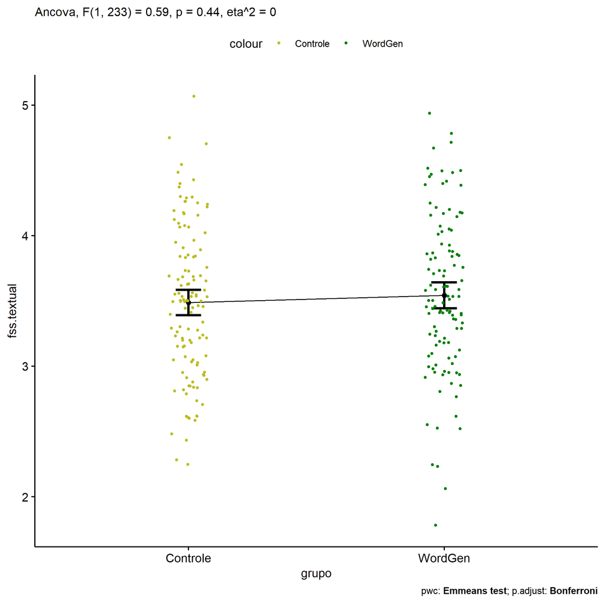

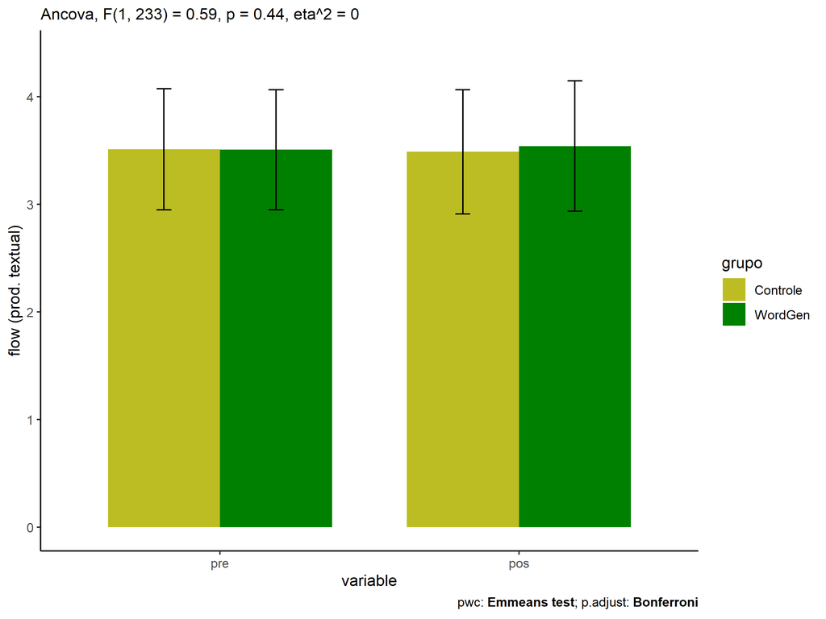

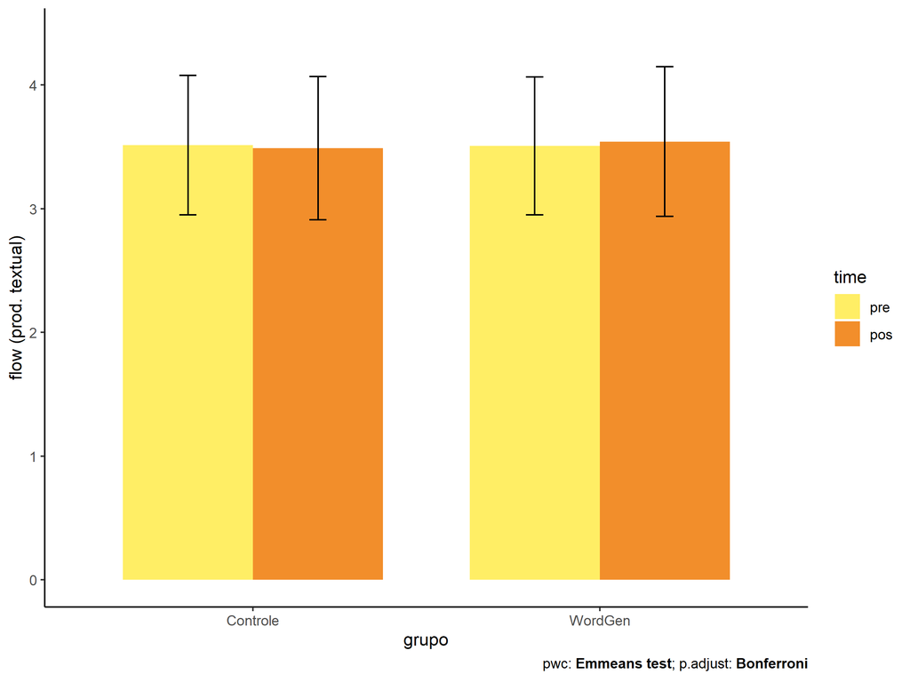

### factor: **genero**

| var | genero | n | M (pre) | SE (pre) | M (unadj) | SE (unadj) | M (adj) | SE (adj) |
| --- | --- | --- | --- | --- | --- | --- | --- | --- |
| fss.textual | F | 112 | 3.567 | 0.053 | 3.632 | 0.055 | 3.609 | 0.051 |
| fss.textual | M | 124 | 3.459 | 0.049 | 3.409 | 0.052 | 3.430 | 0.048 |

| .y. | group1 | group2 | estimate | conf.low | conf.high | se | statistic | p | p.adj | p.adj.signif |
| --- | --- | --- | --- | --- | --- | --- | --- | --- | --- | --- |
| fss.textual | F | M | 0.179 | 0.040 | 0.318 | 0.071 | 2.540 | 0.012 | 0.012 | * |
| dfs.textual | F | M | 0.108 | -0.035 | 0.251 | 0.073 | 1.488 | 0.138 | 0.138 | ns |

| .y. | genero | group1 | group2 | estimate | conf.low | conf.high | se | statistic | p | p.adj | p.adj.signif |
| --- | --- | --- | --- | --- | --- | --- | --- | --- | --- | --- | --- |
| flow.textual | F | pre | pos | -0.065 | -0.214 | 0.085 | 0.076 | -0.848 | 0.397 | 0.397 | ns |
| flow.textual | M | pre | pos | 0.050 | -0.093 | 0.192 | 0.072 | 0.685 | 0.494 | 0.494 | ns |

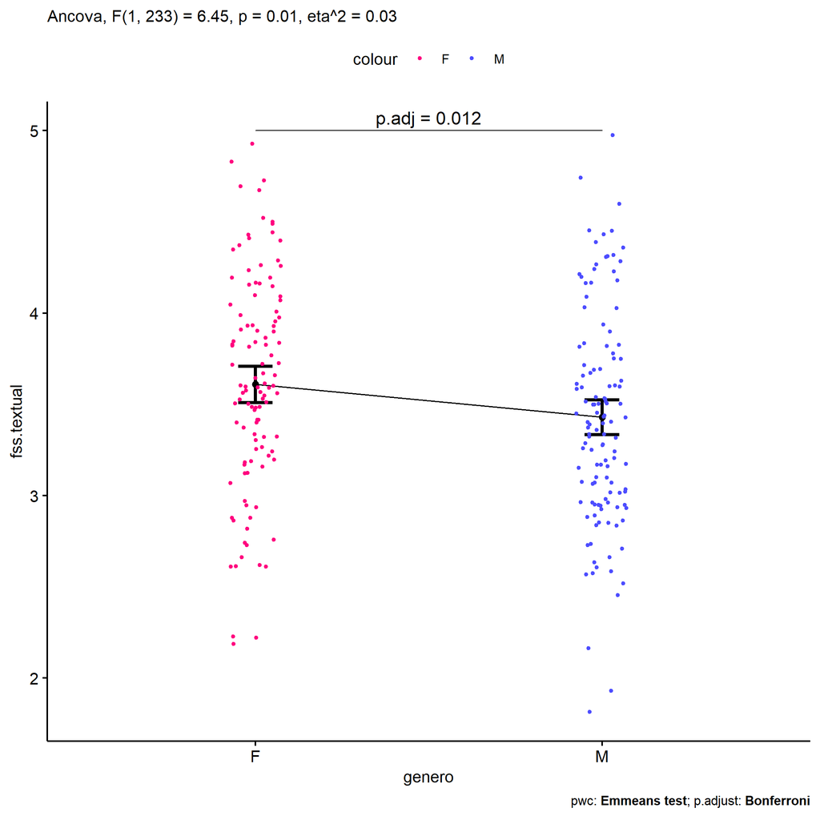

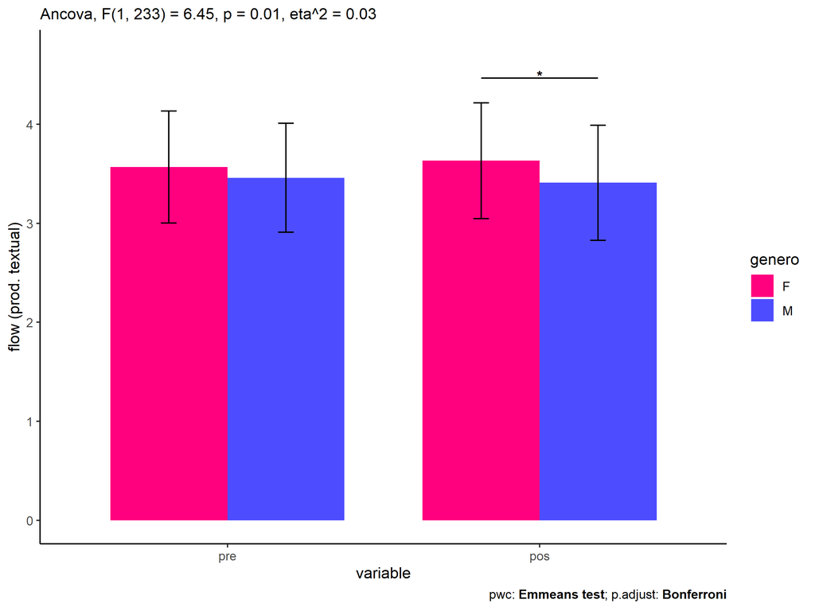

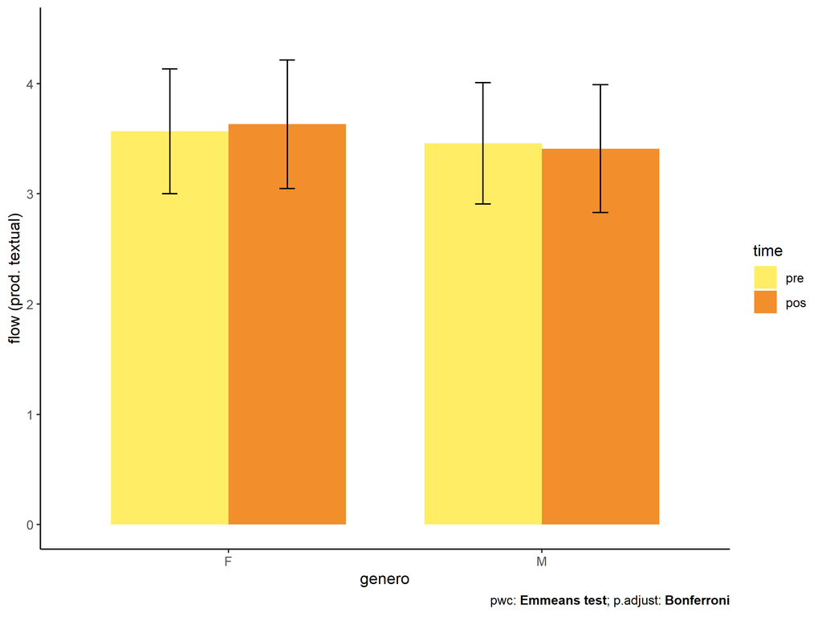

### factor: **idade**

| var | idade | n | M (pre) | SE (pre) | M (unadj) | SE (unadj) | M (adj) | SE (adj) |
| --- | --- | --- | --- | --- | --- | --- | --- | --- |
| fss.textual | 10y | 45 | 3.485 | 0.090 | 3.531 | 0.086 | 3.549 | 0.080 |
| fss.textual | 11y | 134 | 3.590 | 0.046 | 3.595 | 0.051 | 3.571 | 0.047 |
| fss.textual | 12y | 32 | 3.428 | 0.097 | 3.437 | 0.102 | 3.476 | 0.095 |
| fss.textual | 13y | 13 | 3.302 | 0.134 | 2.981 | 0.124 | 3.069 | 0.150 |

| .y. | group1 | group2 | estimate | conf.low | conf.high | se | statistic | p | p.adj | p.adj.signif |
| --- | --- | --- | --- | --- | --- | --- | --- | --- | --- | --- |
| fss.textual | 10y | 11y | -0.022 | -0.205 | 0.161 | 0.093 | -0.239 | 0.812 | 1.000 | ns |
| fss.textual | 10y | 12y | 0.072 | -0.173 | 0.318 | 0.124 | 0.583 | 0.561 | 1.000 | ns |
| fss.textual | 10y | 13y | 0.480 | 0.145 | 0.814 | 0.170 | 2.825 | 0.005 | 0.031 | * |
| fss.textual | 11y | 12y | 0.095 | -0.115 | 0.304 | 0.106 | 0.890 | 0.374 | 1.000 | ns |
| fss.textual | 11y | 13y | 0.502 | 0.192 | 0.812 | 0.157 | 3.189 | 0.002 | 0.010 | ** |
| fss.textual | 12y | 13y | 0.407 | 0.058 | 0.756 | 0.177 | 2.299 | 0.022 | 0.135 | ns |
| dfs.textual | 10y | 11y | -0.105 | -0.293 | 0.082 | 0.095 | -1.109 | 0.268 | 1.000 | ns |
| dfs.textual | 10y | 12y | 0.056 | -0.195 | 0.307 | 0.127 | 0.441 | 0.660 | 1.000 | ns |
| dfs.textual | 10y | 13y | 0.182 | -0.160 | 0.524 | 0.174 | 1.050 | 0.295 | 1.000 | ns |
| dfs.textual | 11y | 12y | 0.162 | -0.052 | 0.375 | 0.108 | 1.490 | 0.138 | 0.827 | ns |
| dfs.textual | 11y | 13y | 0.288 | -0.028 | 0.603 | 0.160 | 1.796 | 0.074 | 0.443 | ns |
| dfs.textual | 12y | 13y | 0.126 | -0.231 | 0.483 | 0.181 | 0.695 | 0.488 | 1.000 | ns |

| .y. | idade | group1 | group2 | estimate | conf.low | conf.high | se | statistic | p | p.adj | p.adj.signif |
| --- | --- | --- | --- | --- | --- | --- | --- | --- | --- | --- | --- |
| flow.textual | 10y | pre | pos | -0.047 | -0.281 | 0.187 | 0.119 | -0.394 | 0.694 | 0.694 | ns |
| flow.textual | 11y | pre | pos | -0.005 | -0.141 | 0.131 | 0.069 | -0.071 | 0.943 | 0.943 | ns |
| flow.textual | 12y | pre | pos | -0.009 | -0.286 | 0.269 | 0.141 | -0.061 | 0.951 | 0.951 | ns |
| flow.textual | 13y | pre | pos | 0.322 | -0.114 | 0.757 | 0.222 | 1.452 | 0.147 | 0.147 | ns |

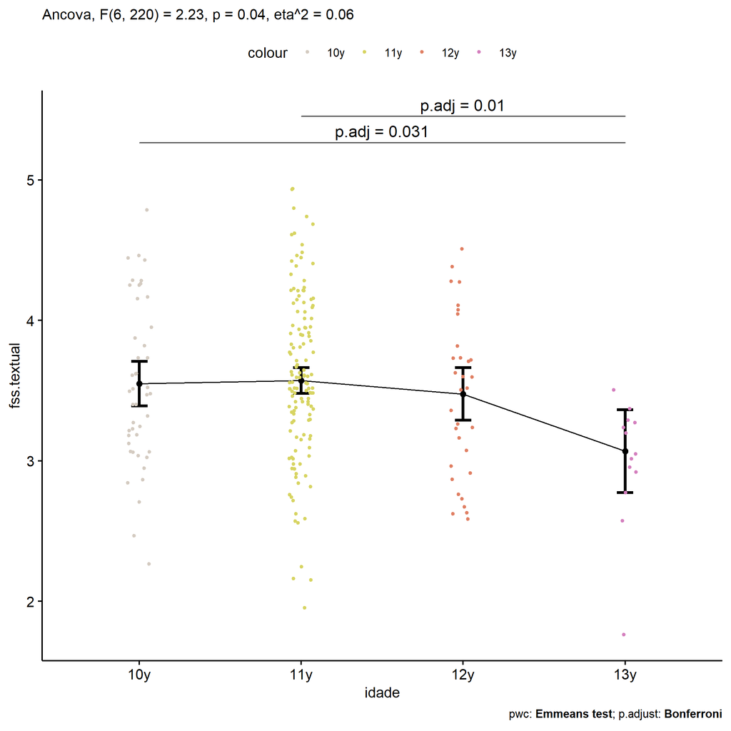

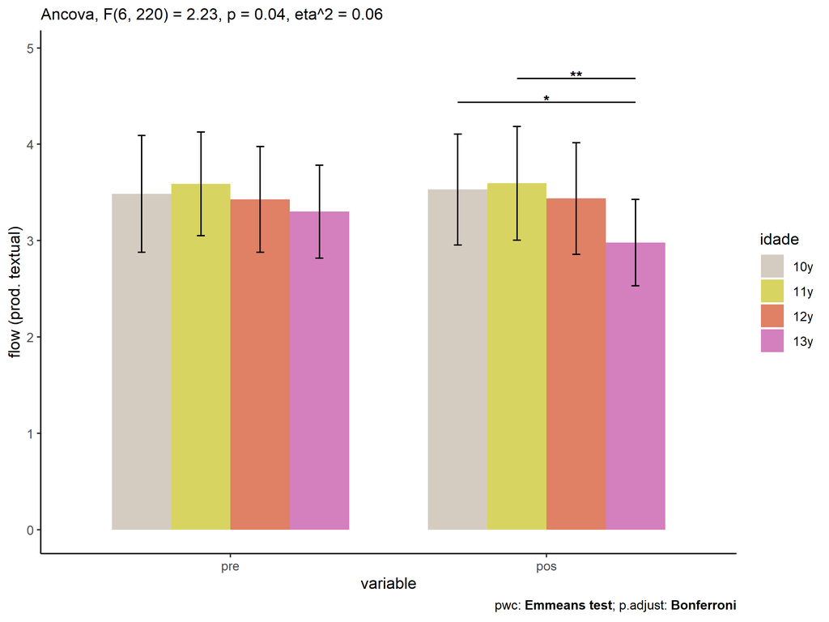

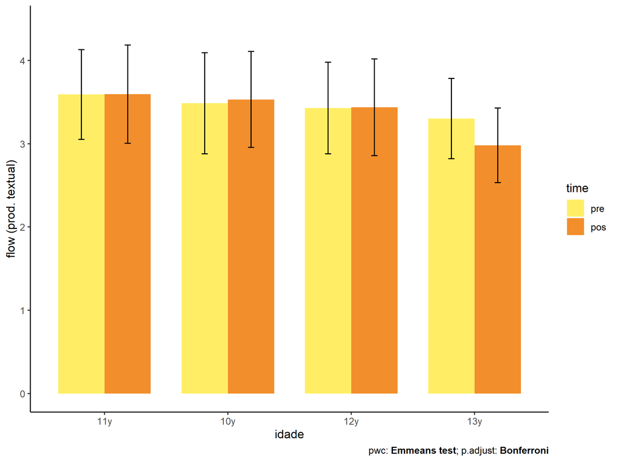

### factor: **zona.participante**

| var | zona.participante | n | M (pre) | SE (pre) | M (unadj) | SE (unadj) | M (adj) | SE (adj) |
| --- | --- | --- | --- | --- | --- | --- | --- | --- |
| fss.textual | Rural | 89 | 3.515 | 0.062 | 3.469 | 0.066 | 3.463 | 0.058 |
| fss.textual | Urbana | 96 | 3.489 | 0.060 | 3.551 | 0.058 | 3.556 | 0.056 |

| .y. | group1 | group2 | estimate | conf.low | conf.high | se | statistic | p | p.adj | p.adj.signif |
| --- | --- | --- | --- | --- | --- | --- | --- | --- | --- | --- |
| fss.textual | Urbana | Rural | 0.092 | -0.067 | 0.251 | 0.081 | 1.146 | 0.253 | 0.253 | ns |
| dfs.textual | Urbana | Rural | -0.026 | -0.196 | 0.144 | 0.086 | -0.302 | 0.763 | 0.763 | ns |

| .y. | zona.participante | group1 | group2 | estimate | conf.low | conf.high | se | statistic | p | p.adj | p.adj.signif |
| --- | --- | --- | --- | --- | --- | --- | --- | --- | --- | --- | --- |
| flow.textual | Urbana | pre | pos | -0.062 | -0.229 | 0.106 | 0.085 | -0.725 | 0.469 | 0.469 | ns |
| flow.textual | Rural | pre | pos | 0.046 | -0.128 | 0.220 | 0.089 | 0.519 | 0.604 | 0.604 | ns |

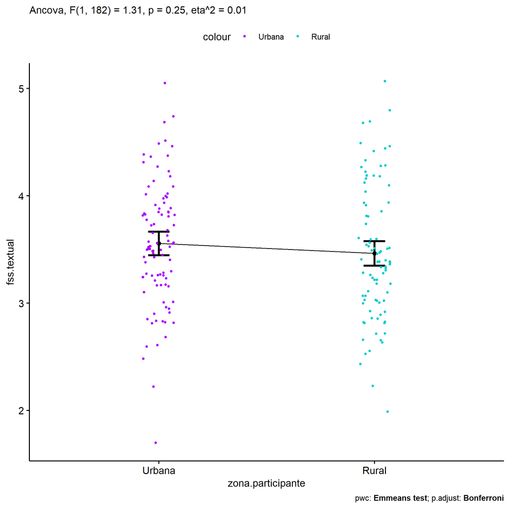

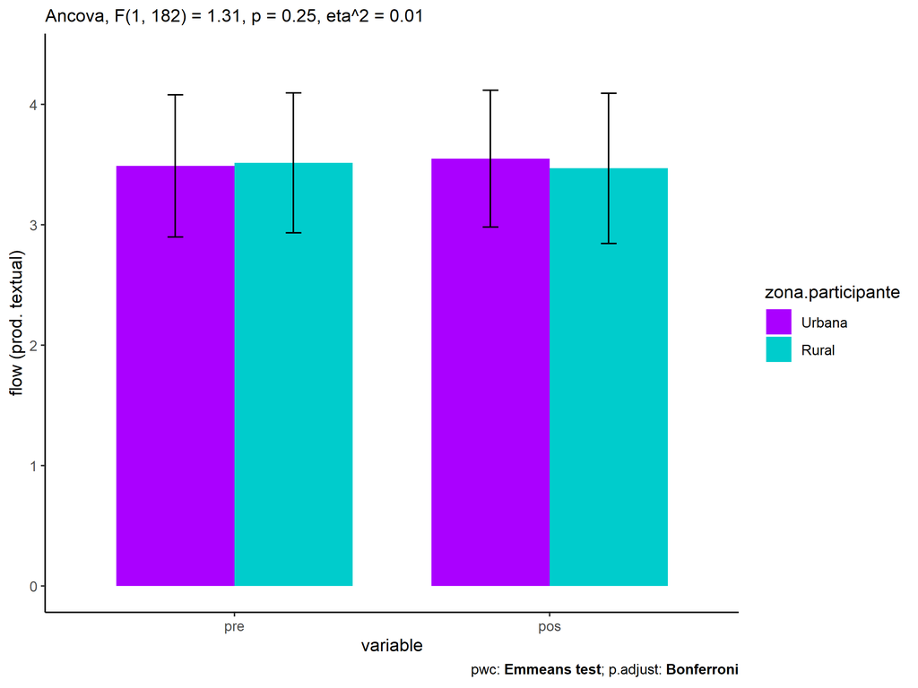

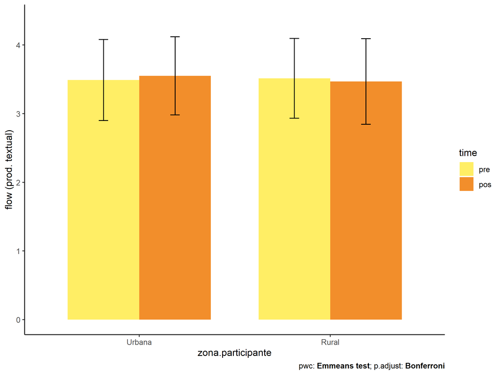

### factor: **escola**

| var | escola | n | M (pre) | SE (pre) | M (unadj) | SE (unadj) | M (adj) | SE (adj) |
| --- | --- | --- | --- | --- | --- | --- | --- | --- |
| fss.textual | E1 | 21 | 3.388 | 0.121 | 3.721 | 0.133 | 3.773 | 0.118 |
| fss.textual | E2 | 47 | 3.480 | 0.076 | 3.418 | 0.093 | 3.431 | 0.079 |
| fss.textual | E3 | 28 | 3.560 | 0.120 | 3.394 | 0.106 | 3.373 | 0.102 |
| fss.textual | E4 | 25 | 3.581 | 0.095 | 3.461 | 0.113 | 3.430 | 0.108 |
| fss.textual | E5 | 93 | 3.490 | 0.064 | 3.542 | 0.060 | 3.550 | 0.056 |
| fss.textual | E6 | 22 | 3.631 | 0.083 | 3.626 | 0.122 | 3.575 | 0.115 |

| .y. | group1 | group2 | estimate | conf.low | conf.high | se | statistic | p | p.adj | p.adj.signif |
| --- | --- | --- | --- | --- | --- | --- | --- | --- | --- | --- |
| fss.textual | E1 | E2 | 0.342 | 0.063 | 0.622 | 0.142 | 2.412 | 0.017 | 0.249 | ns |
| fss.textual | E1 | E3 | 0.400 | 0.092 | 0.708 | 0.156 | 2.558 | 0.011 | 0.168 | ns |
| fss.textual | E1 | E4 | 0.342 | 0.027 | 0.658 | 0.160 | 2.136 | 0.034 | 0.506 | ns |
| fss.textual | E1 | E5 | 0.223 | -0.035 | 0.480 | 0.131 | 1.704 | 0.090 | 1.000 | ns |
| fss.textual | E1 | E6 | 0.198 | -0.128 | 0.524 | 0.165 | 1.197 | 0.232 | 1.000 | ns |
| fss.textual | E2 | E3 | 0.057 | -0.197 | 0.312 | 0.129 | 0.446 | 0.656 | 1.000 | ns |
| fss.textual | E2 | E4 | 0.000 | -0.263 | 0.264 | 0.134 | 0.001 | 0.999 | 1.000 | ns |
| fss.textual | E2 | E5 | -0.120 | -0.310 | 0.071 | 0.097 | -1.238 | 0.217 | 1.000 | ns |
| fss.textual | E2 | E6 | -0.144 | -0.420 | 0.131 | 0.140 | -1.031 | 0.304 | 1.000 | ns |
| fss.textual | E3 | E4 | -0.057 | -0.350 | 0.235 | 0.149 | -0.386 | 0.700 | 1.000 | ns |
| fss.textual | E3 | E5 | -0.177 | -0.407 | 0.052 | 0.116 | -1.520 | 0.130 | 1.000 | ns |
| fss.textual | E3 | E6 | -0.202 | -0.505 | 0.102 | 0.154 | -1.310 | 0.192 | 1.000 | ns |
| fss.textual | E4 | E5 | -0.120 | -0.360 | 0.120 | 0.122 | -0.984 | 0.326 | 1.000 | ns |
| fss.textual | E4 | E6 | -0.144 | -0.455 | 0.167 | 0.158 | -0.914 | 0.362 | 1.000 | ns |
| fss.textual | E5 | E6 | -0.025 | -0.277 | 0.228 | 0.128 | -0.191 | 0.849 | 1.000 | ns |
| dfs.textual | E1 | E2 | -0.092 | -0.382 | 0.199 | 0.147 | -0.622 | 0.535 | 1.000 | ns |
| dfs.textual | E1 | E3 | -0.171 | -0.491 | 0.148 | 0.162 | -1.057 | 0.292 | 1.000 | ns |
| dfs.textual | E1 | E4 | -0.193 | -0.520 | 0.135 | 0.166 | -1.160 | 0.247 | 1.000 | ns |
| dfs.textual | E1 | E5 | -0.102 | -0.369 | 0.165 | 0.136 | -0.752 | 0.453 | 1.000 | ns |
| dfs.textual | E1 | E6 | -0.243 | -0.581 | 0.094 | 0.171 | -1.419 | 0.157 | 1.000 | ns |
| dfs.textual | E2 | E3 | -0.080 | -0.344 | 0.185 | 0.134 | -0.594 | 0.553 | 1.000 | ns |
| dfs.textual | E2 | E4 | -0.101 | -0.375 | 0.173 | 0.139 | -0.728 | 0.467 | 1.000 | ns |
| dfs.textual | E2 | E5 | -0.010 | -0.208 | 0.188 | 0.101 | -0.102 | 0.918 | 1.000 | ns |
| dfs.textual | E2 | E6 | -0.151 | -0.437 | 0.134 | 0.145 | -1.044 | 0.297 | 1.000 | ns |
| dfs.textual | E3 | E4 | -0.022 | -0.326 | 0.283 | 0.155 | -0.140 | 0.889 | 1.000 | ns |
| dfs.textual | E3 | E5 | 0.069 | -0.169 | 0.308 | 0.121 | 0.573 | 0.567 | 1.000 | ns |
| dfs.textual | E3 | E6 | -0.072 | -0.387 | 0.243 | 0.160 | -0.449 | 0.654 | 1.000 | ns |
| dfs.textual | E4 | E5 | 0.091 | -0.158 | 0.340 | 0.127 | 0.719 | 0.473 | 1.000 | ns |
| dfs.textual | E4 | E6 | -0.050 | -0.374 | 0.273 | 0.164 | -0.306 | 0.760 | 1.000 | ns |
| dfs.textual | E5 | E6 | -0.141 | -0.404 | 0.121 | 0.133 | -1.060 | 0.290 | 1.000 | ns |

| .y. | escola | group1 | group2 | estimate | conf.low | conf.high | se | statistic | p | p.adj | p.adj.signif |
| --- | --- | --- | --- | --- | --- | --- | --- | --- | --- | --- | --- |
| flow.textual | E1 | pre | pos | -0.333 | -0.682 | 0.016 | 0.178 | -1.873 | 0.062 | 0.062 | ns |
| flow.textual | E2 | pre | pos | 0.062 | -0.171 | 0.296 | 0.119 | 0.524 | 0.601 | 0.601 | ns |
| flow.textual | E3 | pre | pos | 0.165 | -0.137 | 0.468 | 0.154 | 1.075 | 0.283 | 0.283 | ns |
| flow.textual | E4 | pre | pos | 0.121 | -0.199 | 0.441 | 0.163 | 0.740 | 0.459 | 0.459 | ns |
| flow.textual | E5 | pre | pos | -0.051 | -0.217 | 0.114 | 0.084 | -0.610 | 0.542 | 0.542 | ns |
| flow.textual | E6 | pre | pos | 0.005 | -0.336 | 0.346 | 0.174 | 0.030 | 0.976 | 0.976 | ns |

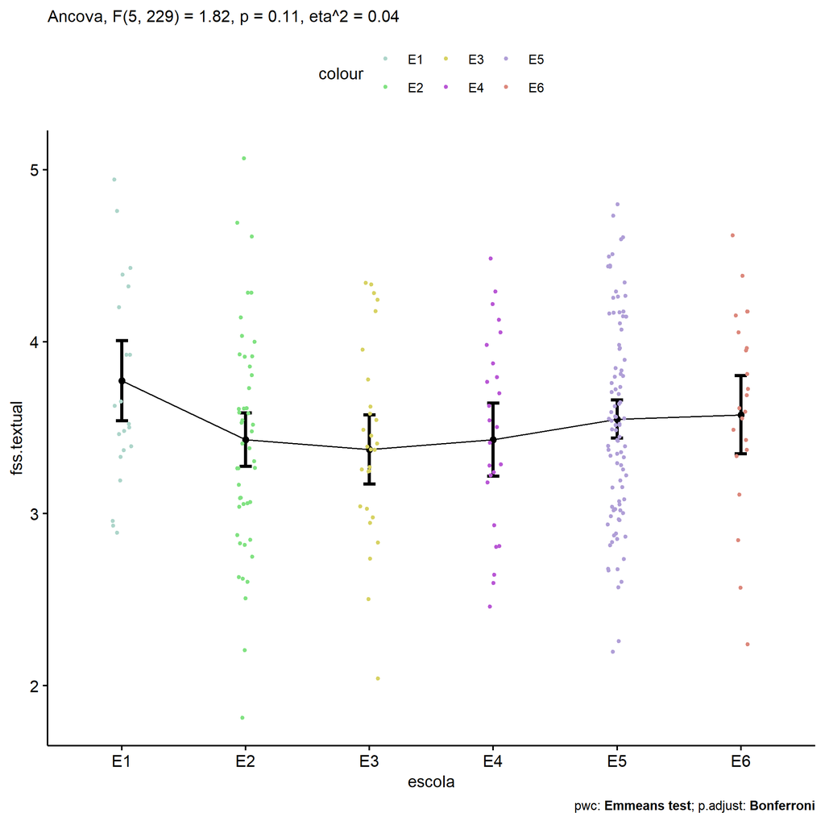

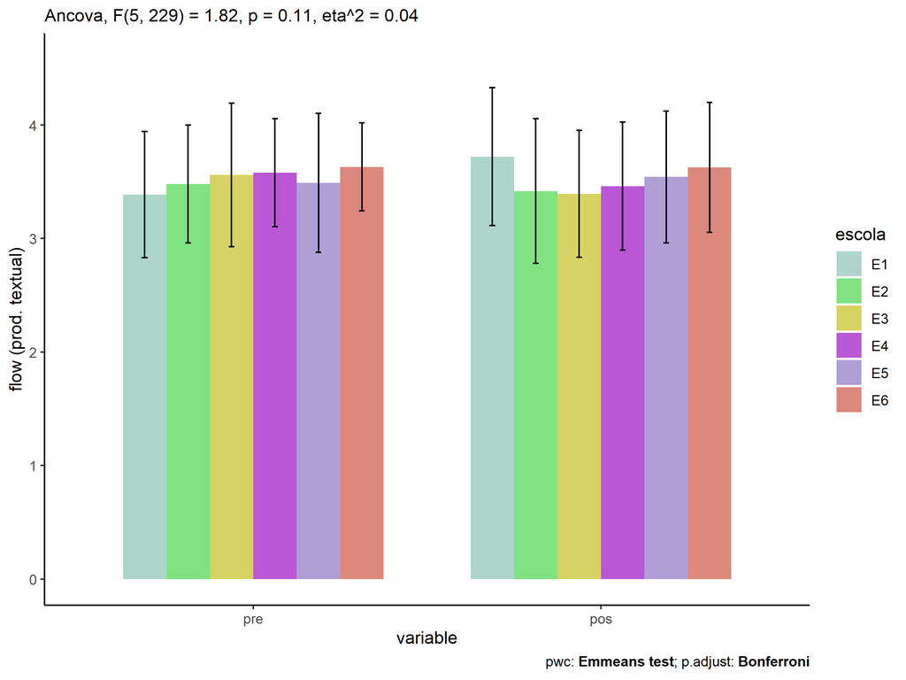

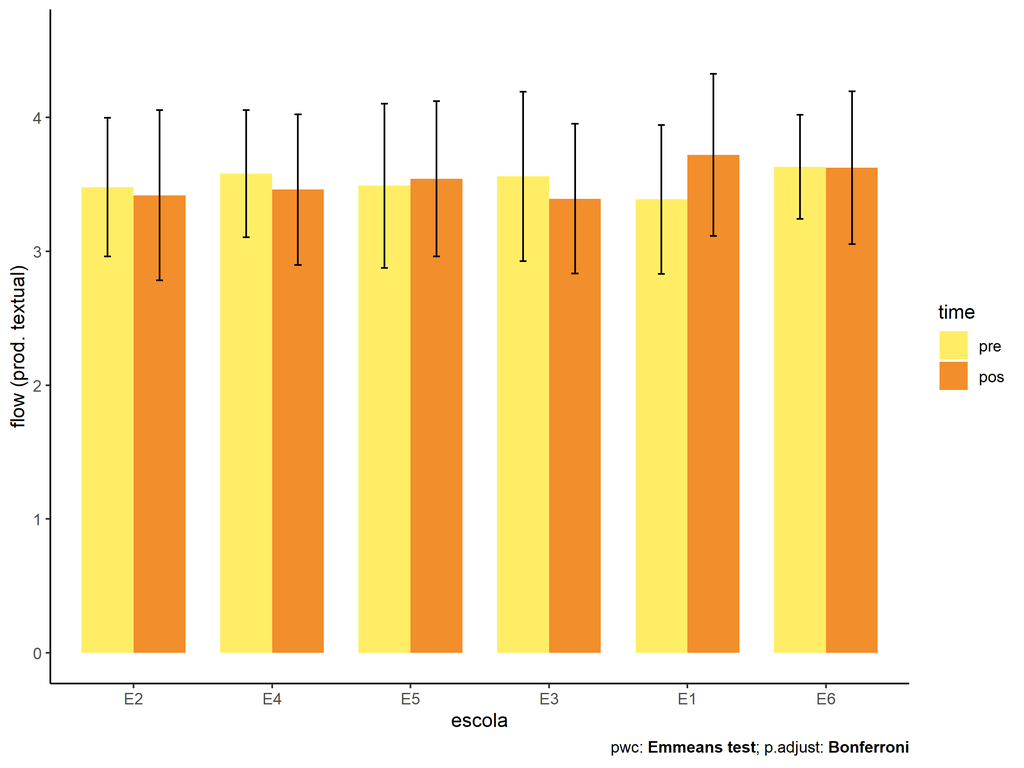

### factor: **zona.escola**

| var | zona.escola | n | M (pre) | SE (pre) | M (unadj) | SE (unadj) | M (adj) | SE (adj) |
| --- | --- | --- | --- | --- | --- | --- | --- | --- |
| fss.textual | Rural | 75 | 3.588 | 0.059 | 3.484 | 0.065 | 3.452 | 0.063 |
| fss.textual | Urbana | 161 | 3.474 | 0.045 | 3.529 | 0.048 | 3.544 | 0.043 |

| .y. | group1 | group2 | estimate | conf.low | conf.high | se | statistic | p | p.adj | p.adj.signif |
| --- | --- | --- | --- | --- | --- | --- | --- | --- | --- | --- |
| fss.textual | Urbana | Rural | 0.093 | -0.058 | 0.243 | 0.076 | 1.211 | 0.227 | 0.227 | ns |
| dfs.textual | Urbana | Rural | -0.114 | -0.268 | 0.040 | 0.078 | -1.461 | 0.145 | 0.145 | ns |

| .y. | zona.escola | group1 | group2 | estimate | conf.low | conf.high | se | statistic | p | p.adj | p.adj.signif |
| --- | --- | --- | --- | --- | --- | --- | --- | --- | --- | --- | --- |
| flow.textual | Urbana | pre | pos | -0.055 | -0.181 | 0.071 | 0.064 | -0.857 | 0.392 | 0.392 | ns |
| flow.textual | Rural | pre | pos | 0.103 | -0.081 | 0.288 | 0.094 | 1.102 | 0.271 | 0.271 | ns |

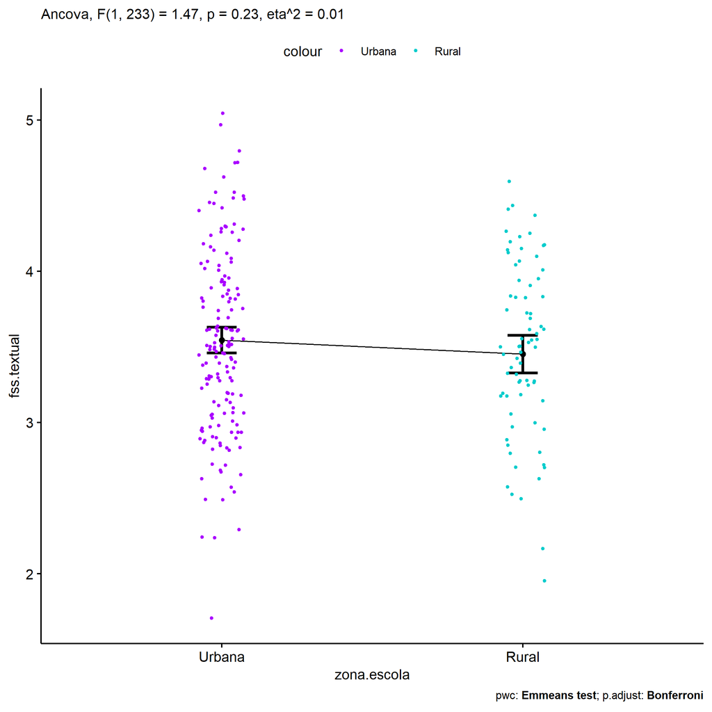

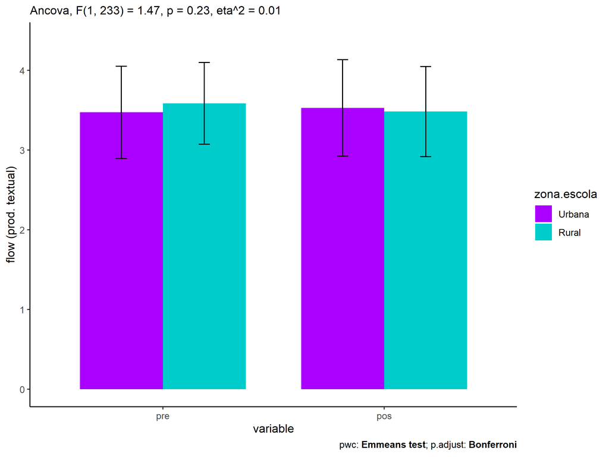

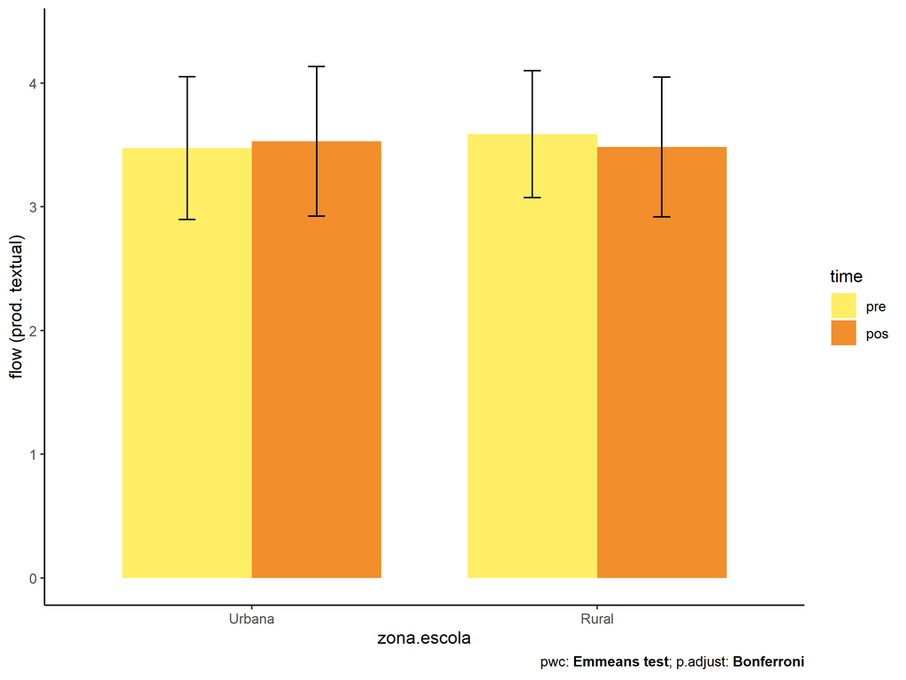

## Pairwise comparisons for two factors

### factores: **grupo:genero**

| var | grupo | genero | n | M (pre) | SE (pre) | M (unadj) | SE (unadj) | M (adj) | SE (adj) |
| --- | --- | --- | --- | --- | --- | --- | --- | --- | --- |
| fss.textual | Controle | F | 59 | 3.536 | 0.077 | 3.542 | 0.079 | 3.531 | 0.070 |
| fss.textual | Controle | M | 62 | 3.490 | 0.068 | 3.439 | 0.070 | 3.447 | 0.068 |
| fss.textual | WordGen | F | 53 | 3.601 | 0.074 | 3.732 | 0.075 | 3.696 | 0.074 |
| fss.textual | WordGen | M | 62 | 3.428 | 0.072 | 3.379 | 0.078 | 3.412 | 0.068 |

| .y. | grupo | genero | group1 | group2 | estimate | conf.low | conf.high | se | statistic | p | p.adj | p.adj.signif |
| --- | --- | --- | --- | --- | --- | --- | --- | --- | --- | --- | --- | --- |
| fss.textual |  | F | Controle | WordGen | -0.165 | -0.365 | 0.036 | 0.102 | -1.618 | 0.107 | 0.107 | ns |
| fss.textual |  | M | Controle | WordGen | 0.035 | -0.155 | 0.226 | 0.097 | 0.366 | 0.715 | 0.715 | ns |
| dfs.textual |  | F | Controle | WordGen | -0.064 | -0.273 | 0.144 | 0.106 | -0.608 | 0.544 | 0.544 | ns |
| dfs.textual |  | M | Controle | WordGen | 0.062 | -0.136 | 0.260 | 0.100 | 0.616 | 0.539 | 0.539 | ns |
| fss.textual | Controle |  | F | M | 0.084 | -0.109 | 0.277 | 0.098 | 0.859 | 0.391 | 0.391 | ns |
| fss.textual | WordGen |  | F | M | 0.284 | 0.085 | 0.483 | 0.101 | 2.809 | 0.005 | 0.005 | ** |
| dfs.textual | Controle |  | F | M | 0.047 | -0.154 | 0.247 | 0.102 | 0.460 | 0.646 | 0.646 | ns |
| dfs.textual | WordGen |  | F | M | 0.173 | -0.033 | 0.379 | 0.105 | 1.653 | 0.100 | 0.100 | ns |

| .y. | grupo | genero | group1 | group2 | estimate | conf.low | conf.high | se | statistic | p | p.adj | p.adj.signif |
| --- | --- | --- | --- | --- | --- | --- | --- | --- | --- | --- | --- | --- |
| flow.textual | Controle | F | pre | pos | -0.005 | -0.211 | 0.201 | 0.105 | -0.048 | 0.962 | 0.962 | ns |
| flow.textual | Controle | M | pre | pos | 0.051 | -0.150 | 0.252 | 0.102 | 0.495 | 0.621 | 0.621 | ns |
| flow.textual | WordGen | F | pre | pos | -0.131 | -0.348 | 0.087 | 0.111 | -1.183 | 0.238 | 0.238 | ns |
| flow.textual | WordGen | M | pre | pos | 0.049 | -0.153 | 0.250 | 0.102 | 0.474 | 0.636 | 0.636 | ns |

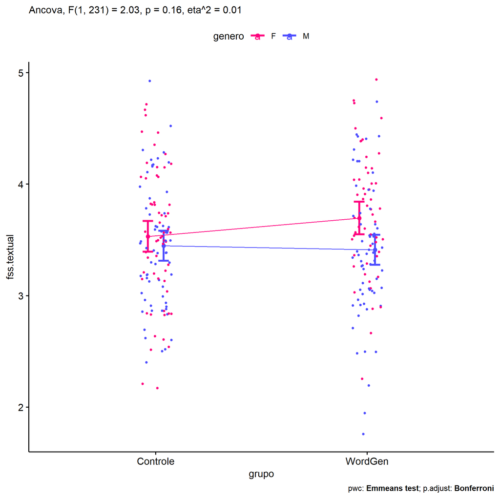

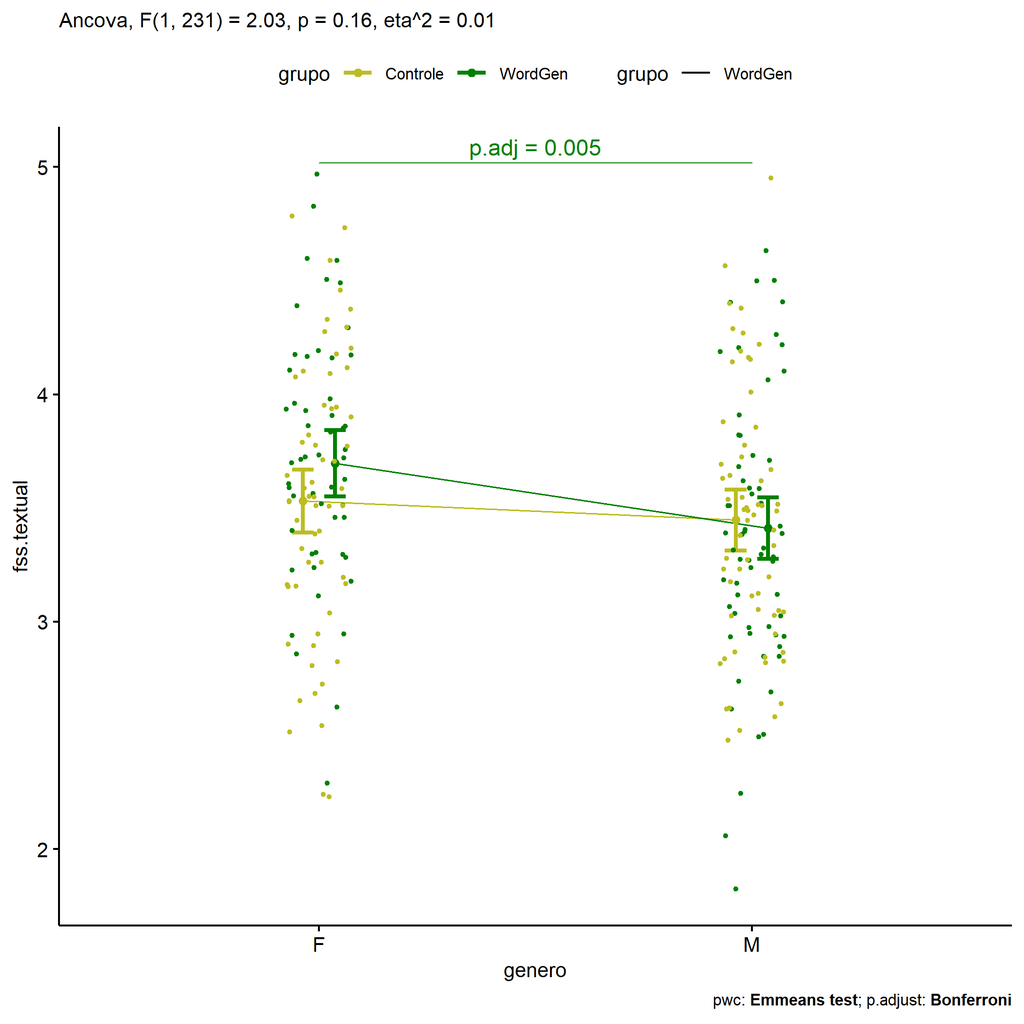

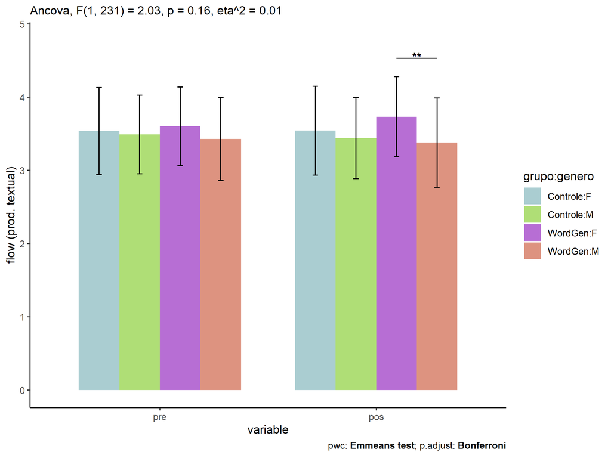

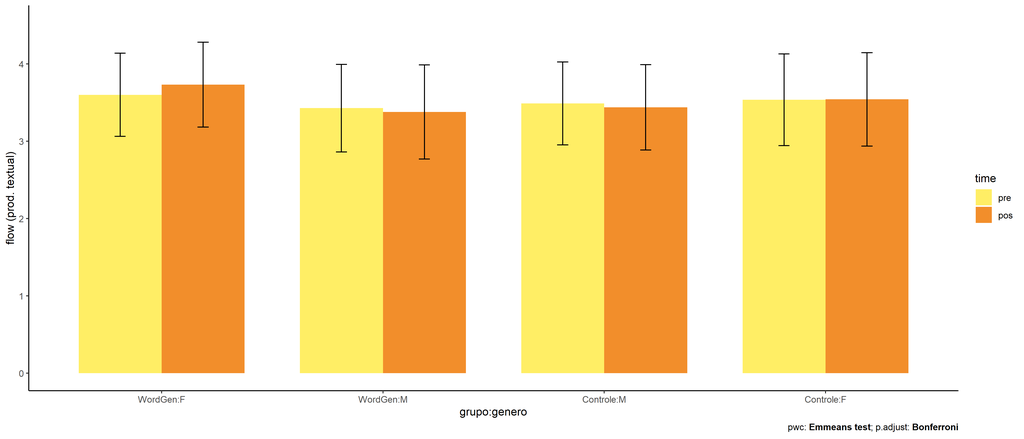

### factores: **grupo:idade**

| var | grupo | idade | n | M (pre) | SE (pre) | M (unadj) | SE (unadj) | M (adj) | SE (adj) |
| --- | --- | --- | --- | --- | --- | --- | --- | --- | --- |
| fss.textual | Controle | 10y | 23 | 3.572 | 0.114 | 3.580 | 0.134 | 3.563 | 0.113 |
| fss.textual | Controle | 11y | 64 | 3.599 | 0.070 | 3.555 | 0.073 | 3.528 | 0.068 |
| fss.textual | Controle | 12y | 18 | 3.367 | 0.121 | 3.351 | 0.136 | 3.413 | 0.128 |
| fss.textual | Controle | 13y | 7 | 3.450 | 0.217 | 3.190 | 0.079 | 3.221 | 0.204 |
| fss.textual | WordGen | 10y | 22 | 3.393 | 0.142 | 3.481 | 0.108 | 3.533 | 0.115 |
| fss.textual | WordGen | 11y | 70 | 3.582 | 0.063 | 3.631 | 0.071 | 3.611 | 0.065 |
| fss.textual | WordGen | 12y | 14 | 3.508 | 0.161 | 3.548 | 0.156 | 3.556 | 0.144 |
| fss.textual | WordGen | 13y | 6 | 3.130 | 0.126 | 2.736 | 0.222 | 2.889 | 0.222 |

| .y. | grupo | idade | group1 | group2 | estimate | conf.low | conf.high | se | statistic | p | p.adj | p.adj.signif |
| --- | --- | --- | --- | --- | --- | --- | --- | --- | --- | --- | --- | --- |
| fss.textual |  | 10y | Controle | WordGen | 0.030 | -0.288 | 0.348 | 0.161 | 0.188 | 0.851 | 0.851 | ns |
| fss.textual |  | 11y | Controle | WordGen | -0.083 | -0.267 | 0.101 | 0.093 | -0.888 | 0.375 | 0.375 | ns |
| fss.textual |  | 12y | Controle | WordGen | -0.142 | -0.522 | 0.237 | 0.192 | -0.740 | 0.460 | 0.460 | ns |
| fss.textual |  | 13y | Controle | WordGen | 0.331 | -0.262 | 0.925 | 0.301 | 1.102 | 0.272 | 0.272 | ns |
| dfs.textual |  | 10y | Controle | WordGen | 0.179 | -0.146 | 0.503 | 0.165 | 1.083 | 0.280 | 0.280 | ns |
| dfs.textual |  | 11y | Controle | WordGen | 0.017 | -0.171 | 0.206 | 0.096 | 0.181 | 0.857 | 0.857 | ns |
| dfs.textual |  | 12y | Controle | WordGen | -0.141 | -0.530 | 0.247 | 0.197 | -0.718 | 0.473 | 0.473 | ns |
| dfs.textual |  | 13y | Controle | WordGen | 0.321 | -0.285 | 0.927 | 0.307 | 1.043 | 0.298 | 0.298 | ns |
| fss.textual | Controle |  | 10y | 11y | 0.035 | -0.223 | 0.294 | 0.131 | 0.268 | 0.789 | 1.000 | ns |
| fss.textual | Controle |  | 10y | 12y | 0.150 | -0.186 | 0.486 | 0.170 | 0.881 | 0.380 | 1.000 | ns |
| fss.textual | Controle |  | 10y | 13y | 0.343 | -0.117 | 0.802 | 0.233 | 1.471 | 0.143 | 0.857 | ns |
| fss.textual | Controle |  | 11y | 12y | 0.115 | -0.170 | 0.400 | 0.145 | 0.794 | 0.428 | 1.000 | ns |
| fss.textual | Controle |  | 11y | 13y | 0.308 | -0.116 | 0.731 | 0.215 | 1.431 | 0.154 | 0.923 | ns |
| fss.textual | Controle |  | 12y | 13y | 0.193 | -0.281 | 0.666 | 0.240 | 0.802 | 0.423 | 1.000 | ns |
| fss.textual | WordGen |  | 10y | 11y | -0.078 | -0.339 | 0.183 | 0.132 | -0.589 | 0.556 | 1.000 | ns |
| fss.textual | WordGen |  | 10y | 12y | -0.023 | -0.386 | 0.341 | 0.185 | -0.123 | 0.902 | 1.000 | ns |
| fss.textual | WordGen |  | 10y | 13y | 0.644 | 0.153 | 1.135 | 0.249 | 2.585 | 0.010 | 0.062 | ns |
| fss.textual | WordGen |  | 11y | 12y | 0.055 | -0.256 | 0.367 | 0.158 | 0.350 | 0.726 | 1.000 | ns |
| fss.textual | WordGen |  | 11y | 13y | 0.722 | 0.266 | 1.178 | 0.231 | 3.120 | 0.002 | 0.012 | * |
| fss.textual | WordGen |  | 12y | 13y | 0.667 | 0.145 | 1.188 | 0.264 | 2.521 | 0.012 | 0.075 | ns |
| dfs.textual | Controle |  | 10y | 11y | -0.027 | -0.292 | 0.238 | 0.134 | -0.202 | 0.840 | 1.000 | ns |
| dfs.textual | Controle |  | 10y | 12y | 0.205 | -0.137 | 0.548 | 0.174 | 1.181 | 0.239 | 1.000 | ns |
| dfs.textual | Controle |  | 10y | 13y | 0.121 | -0.349 | 0.592 | 0.239 | 0.509 | 0.611 | 1.000 | ns |
| dfs.textual | Controle |  | 11y | 12y | 0.232 | -0.058 | 0.523 | 0.147 | 1.576 | 0.116 | 0.698 | ns |
| dfs.textual | Controle |  | 11y | 13y | 0.149 | -0.285 | 0.582 | 0.220 | 0.675 | 0.500 | 1.000 | ns |
| dfs.textual | Controle |  | 12y | 13y | -0.084 | -0.569 | 0.401 | 0.246 | -0.341 | 0.734 | 1.000 | ns |
| dfs.textual | WordGen |  | 10y | 11y | -0.188 | -0.455 | 0.078 | 0.135 | -1.394 | 0.165 | 0.988 | ns |
| dfs.textual | WordGen |  | 10y | 12y | -0.115 | -0.487 | 0.258 | 0.189 | -0.607 | 0.545 | 1.000 | ns |
| dfs.textual | WordGen |  | 10y | 13y | 0.264 | -0.238 | 0.765 | 0.255 | 1.036 | 0.301 | 1.000 | ns |
| dfs.textual | WordGen |  | 11y | 12y | 0.074 | -0.245 | 0.393 | 0.162 | 0.456 | 0.649 | 1.000 | ns |
| dfs.textual | WordGen |  | 11y | 13y | 0.452 | -0.011 | 0.915 | 0.235 | 1.923 | 0.056 | 0.335 | ns |
| dfs.textual | WordGen |  | 12y | 13y | 0.378 | -0.153 | 0.910 | 0.270 | 1.403 | 0.162 | 0.973 | ns |

| .y. | grupo | idade | group1 | group2 | estimate | conf.low | conf.high | se | statistic | p | p.adj | p.adj.signif |
| --- | --- | --- | --- | --- | --- | --- | --- | --- | --- | --- | --- | --- |
| flow.textual | Controle | 10y | pre | pos | -0.008 | -0.336 | 0.320 | 0.167 | -0.047 | 0.962 | 0.962 | ns |
| flow.textual | Controle | 11y | pre | pos | 0.044 | -0.153 | 0.240 | 0.100 | 0.440 | 0.660 | 0.660 | ns |
| flow.textual | Controle | 12y | pre | pos | 0.015 | -0.355 | 0.386 | 0.189 | 0.082 | 0.935 | 0.935 | ns |
| flow.textual | Controle | 13y | pre | pos | 0.260 | -0.334 | 0.854 | 0.302 | 0.860 | 0.390 | 0.390 | ns |
| flow.textual | WordGen | 10y | pre | pos | -0.088 | -0.423 | 0.247 | 0.171 | -0.515 | 0.607 | 0.607 | ns |
| flow.textual | WordGen | 11y | pre | pos | -0.050 | -0.237 | 0.138 | 0.096 | -0.519 | 0.604 | 0.604 | ns |
| flow.textual | WordGen | 12y | pre | pos | -0.040 | -0.460 | 0.381 | 0.214 | -0.186 | 0.853 | 0.853 | ns |
| flow.textual | WordGen | 13y | pre | pos | 0.394 | -0.248 | 1.035 | 0.327 | 1.205 | 0.229 | 0.229 | ns |

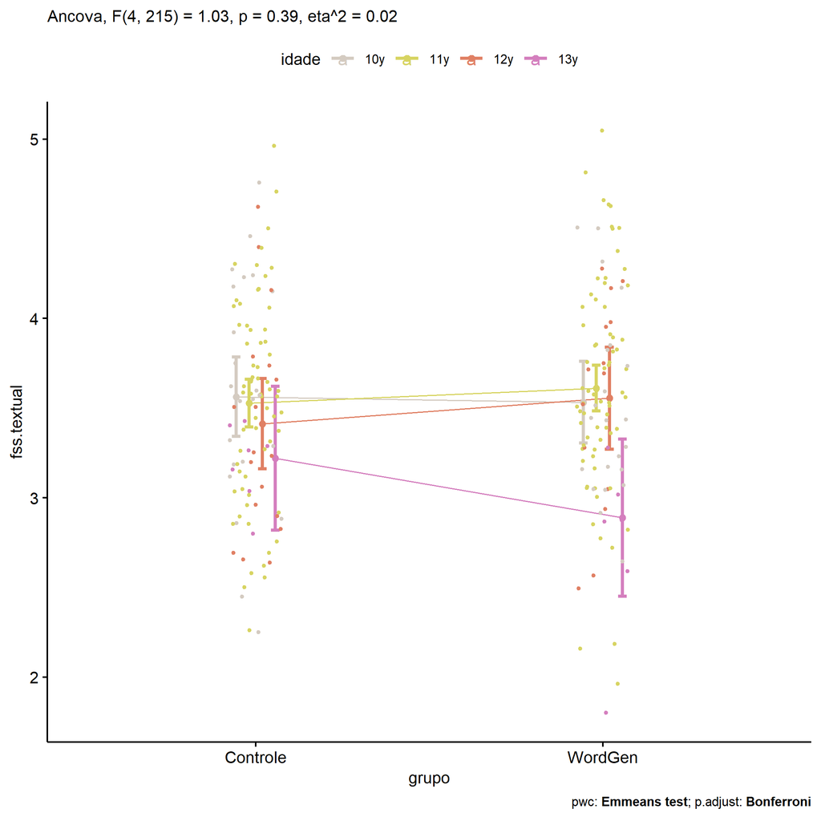

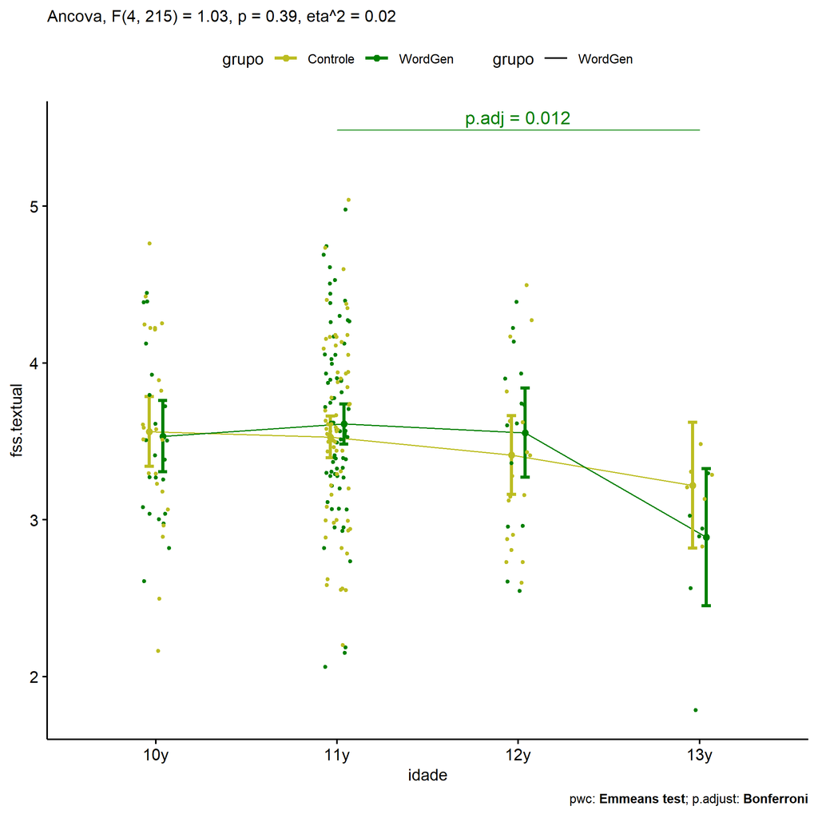

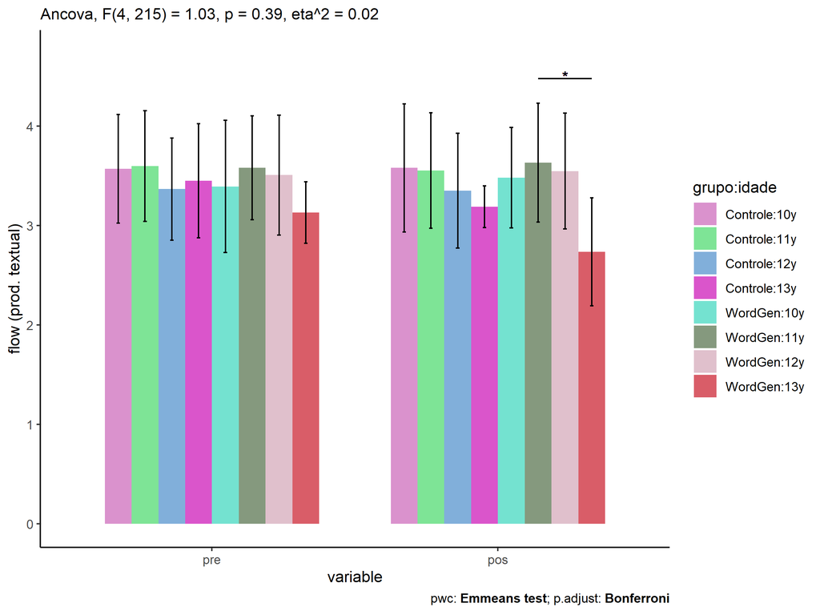

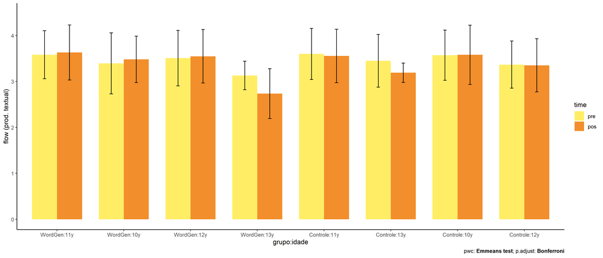

### factores: **grupo:zona.participante**

| var | grupo | zona.participante | n | M (pre) | SE (pre) | M (unadj) | SE (unadj) | M (adj) | SE (adj) |
| --- | --- | --- | --- | --- | --- | --- | --- | --- | --- |
| fss.textual | Controle | Rural | 42 | 3.514 | 0.088 | 3.370 | 0.089 | 3.365 | 0.084 |
| fss.textual | Controle | Urbana | 53 | 3.535 | 0.082 | 3.553 | 0.081 | 3.539 | 0.075 |
| fss.textual | WordGen | Rural | 47 | 3.515 | 0.087 | 3.557 | 0.096 | 3.551 | 0.080 |
| fss.textual | WordGen | Urbana | 43 | 3.432 | 0.089 | 3.548 | 0.084 | 3.576 | 0.083 |

| .y. | grupo | zona.participante | group1 | group2 | estimate | conf.low | conf.high | se | statistic | p | p.adj | p.adj.signif |
| --- | --- | --- | --- | --- | --- | --- | --- | --- | --- | --- | --- | --- |
| fss.textual |  | Urbana | Controle | WordGen | -0.037 | -0.259 | 0.185 | 0.112 | -0.329 | 0.743 | 0.743 | ns |
| fss.textual |  | Rural | Controle | WordGen | -0.187 | -0.415 | 0.042 | 0.116 | -1.610 | 0.109 | 0.109 | ns |
| dfs.textual |  | Urbana | Controle | WordGen | 0.103 | -0.135 | 0.341 | 0.121 | 0.852 | 0.395 | 0.395 | ns |
| dfs.textual |  | Rural | Controle | WordGen | -0.001 | -0.248 | 0.245 | 0.125 | -0.009 | 0.993 | 0.993 | ns |
| fss.textual | Controle |  | Urbana | Rural | 0.174 | -0.048 | 0.397 | 0.113 | 1.545 | 0.124 | 0.124 | ns |
| fss.textual | WordGen |  | Urbana | Rural | 0.025 | -0.203 | 0.252 | 0.115 | 0.213 | 0.831 | 0.831 | ns |
| dfs.textual | Controle |  | Urbana | Rural | 0.021 | -0.219 | 0.260 | 0.122 | 0.170 | 0.865 | 0.865 | ns |
| dfs.textual | WordGen |  | Urbana | Rural | -0.083 | -0.328 | 0.162 | 0.124 | -0.672 | 0.503 | 0.503 | ns |

| .y. | grupo | zona.participante | group1 | group2 | estimate | conf.low | conf.high | se | statistic | p | p.adj | p.adj.signif |
| --- | --- | --- | --- | --- | --- | --- | --- | --- | --- | --- | --- | --- |
| flow.textual | Controle | Urbana | pre | pos | -0.018 | -0.244 | 0.208 | 0.115 | -0.156 | 0.876 | 0.876 | ns |
| flow.textual | Controle | Rural | pre | pos | 0.144 | -0.110 | 0.398 | 0.129 | 1.117 | 0.265 | 0.265 | ns |
| flow.textual | WordGen | Urbana | pre | pos | -0.116 | -0.367 | 0.135 | 0.128 | -0.908 | 0.365 | 0.365 | ns |
| flow.textual | WordGen | Rural | pre | pos | -0.042 | -0.282 | 0.198 | 0.122 | -0.342 | 0.732 | 0.732 | ns |

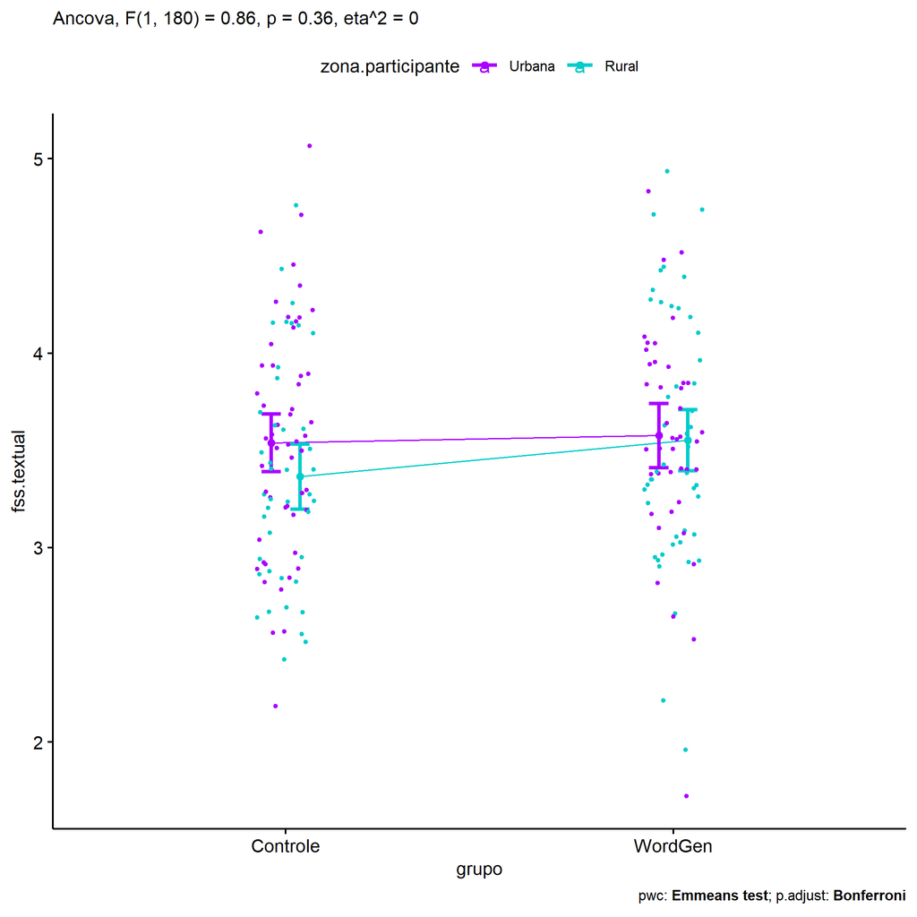

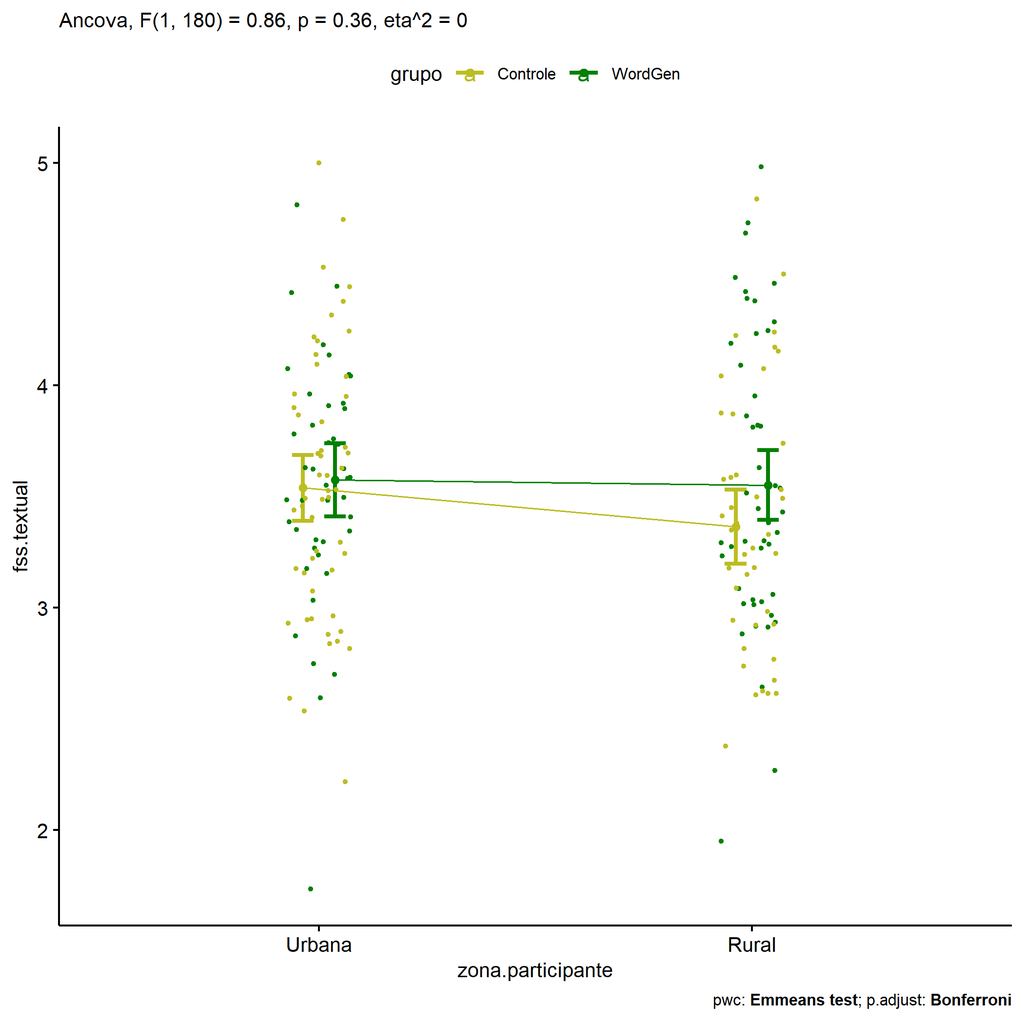

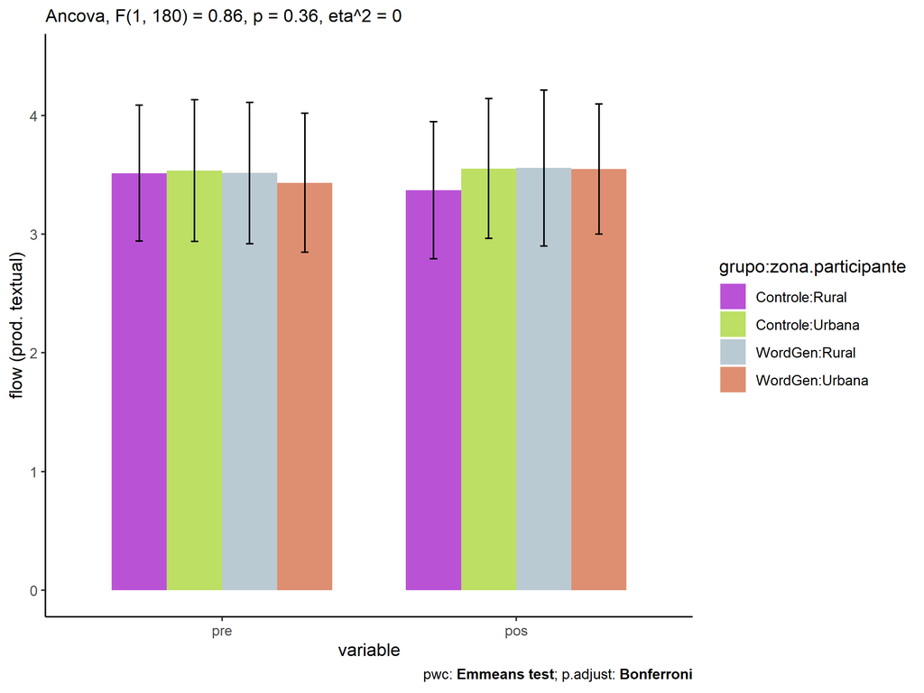

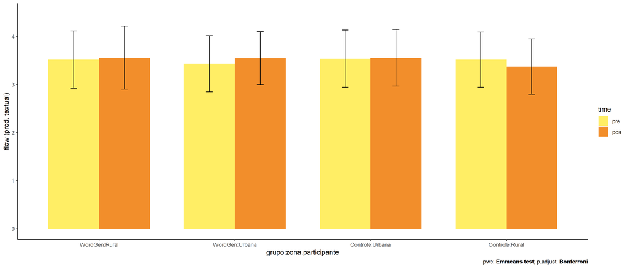

### factores: **grupo:escola**

| var | grupo | escola | n | M (pre) | SE (pre) | M (unadj) | SE (unadj) | M (adj) | SE (adj) |
| --- | --- | --- | --- | --- | --- | --- | --- | --- | --- |
| fss.textual | Controle | E1 | 11 | 3.278 | 0.188 | 3.465 | 0.156 | 3.561 | 0.164 |
| fss.textual | Controle | E2 | 23 | 3.536 | 0.118 | 3.497 | 0.152 | 3.486 | 0.113 |
| fss.textual | Controle | E3 | 14 | 3.588 | 0.145 | 3.348 | 0.110 | 3.316 | 0.144 |
| fss.textual | Controle | E4 | 16 | 3.512 | 0.096 | 3.331 | 0.128 | 3.330 | 0.135 |
| fss.textual | Controle | E5 | 46 | 3.492 | 0.095 | 3.556 | 0.087 | 3.563 | 0.080 |
| fss.textual | Controle | E6 | 11 | 3.686 | 0.106 | 3.626 | 0.162 | 3.554 | 0.163 |
| fss.textual | WordGen | E1 | 10 | 3.510 | 0.149 | 4.003 | 0.189 | 4.003 | 0.171 |
| fss.textual | WordGen | E2 | 24 | 3.426 | 0.096 | 3.341 | 0.109 | 3.376 | 0.110 |
| fss.textual | WordGen | E3 | 14 | 3.531 | 0.195 | 3.440 | 0.184 | 3.431 | 0.144 |
| fss.textual | WordGen | E4 | 9 | 3.704 | 0.204 | 3.691 | 0.202 | 3.611 | 0.180 |
| fss.textual | WordGen | E5 | 47 | 3.488 | 0.086 | 3.528 | 0.085 | 3.537 | 0.079 |
| fss.textual | WordGen | E6 | 11 | 3.577 | 0.130 | 3.626 | 0.190 | 3.599 | 0.163 |

| .y. | grupo | escola | group1 | group2 | estimate | conf.low | conf.high | se | statistic | p | p.adj | p.adj.signif |
| --- | --- | --- | --- | --- | --- | --- | --- | --- | --- | --- | --- | --- |
| fss.textual |  | E1 | Controle | WordGen | -0.442 | -0.908 | 0.024 | 0.236 | -1.871 | 0.063 | 0.063 | ns |
| fss.textual |  | E2 | Controle | WordGen | 0.110 | -0.201 | 0.421 | 0.158 | 0.699 | 0.485 | 0.485 | ns |
| fss.textual |  | E3 | Controle | WordGen | -0.115 | -0.518 | 0.287 | 0.204 | -0.565 | 0.572 | 0.572 | ns |
| fss.textual |  | E4 | Controle | WordGen | -0.282 | -0.726 | 0.163 | 0.225 | -1.249 | 0.213 | 0.213 | ns |
| fss.textual |  | E5 | Controle | WordGen | 0.026 | -0.194 | 0.247 | 0.112 | 0.234 | 0.815 | 0.815 | ns |
| fss.textual |  | E6 | Controle | WordGen | -0.045 | -0.499 | 0.409 | 0.230 | -0.194 | 0.846 | 0.846 | ns |
| dfs.textual |  | E1 | Controle | WordGen | -0.232 | -0.719 | 0.256 | 0.247 | -0.938 | 0.349 | 0.349 | ns |
| dfs.textual |  | E2 | Controle | WordGen | 0.110 | -0.215 | 0.436 | 0.165 | 0.668 | 0.505 | 0.505 | ns |
| dfs.textual |  | E3 | Controle | WordGen | 0.058 | -0.364 | 0.479 | 0.214 | 0.269 | 0.788 | 0.788 | ns |
| dfs.textual |  | E4 | Controle | WordGen | -0.192 | -0.656 | 0.273 | 0.236 | -0.812 | 0.418 | 0.418 | ns |
| dfs.textual |  | E5 | Controle | WordGen | 0.004 | -0.227 | 0.236 | 0.117 | 0.038 | 0.970 | 0.970 | ns |
| dfs.textual |  | E6 | Controle | WordGen | 0.108 | -0.367 | 0.584 | 0.241 | 0.449 | 0.654 | 0.654 | ns |
| fss.textual | Controle |  | E1 | E2 | 0.074 | -0.317 | 0.466 | 0.199 | 0.373 | 0.710 | 1.000 | ns |
| fss.textual | Controle |  | E1 | E3 | 0.245 | -0.186 | 0.675 | 0.218 | 1.120 | 0.264 | 1.000 | ns |
| fss.textual | Controle |  | E1 | E4 | 0.231 | -0.187 | 0.649 | 0.212 | 1.088 | 0.278 | 1.000 | ns |
| fss.textual | Controle |  | E1 | E5 | -0.003 | -0.361 | 0.356 | 0.182 | -0.014 | 0.989 | 1.000 | ns |
| fss.textual | Controle |  | E1 | E6 | 0.007 | -0.450 | 0.463 | 0.232 | 0.029 | 0.977 | 1.000 | ns |
| fss.textual | Controle |  | E2 | E3 | 0.171 | -0.190 | 0.531 | 0.183 | 0.931 | 0.353 | 1.000 | ns |
| fss.textual | Controle |  | E2 | E4 | 0.157 | -0.190 | 0.503 | 0.176 | 0.891 | 0.374 | 1.000 | ns |
| fss.textual | Controle |  | E2 | E5 | -0.077 | -0.349 | 0.195 | 0.138 | -0.556 | 0.579 | 1.000 | ns |
| fss.textual | Controle |  | E2 | E6 | -0.067 | -0.458 | 0.323 | 0.198 | -0.340 | 0.734 | 1.000 | ns |
| fss.textual | Controle |  | E3 | E4 | -0.014 | -0.404 | 0.376 | 0.198 | -0.071 | 0.944 | 1.000 | ns |
| fss.textual | Controle |  | E3 | E5 | -0.247 | -0.572 | 0.078 | 0.165 | -1.499 | 0.135 | 1.000 | ns |
| fss.textual | Controle |  | E3 | E6 | -0.238 | -0.667 | 0.191 | 0.218 | -1.093 | 0.276 | 1.000 | ns |
| fss.textual | Controle |  | E4 | E5 | -0.233 | -0.542 | 0.076 | 0.157 | -1.488 | 0.138 | 1.000 | ns |
| fss.textual | Controle |  | E4 | E6 | -0.224 | -0.641 | 0.193 | 0.212 | -1.057 | 0.292 | 1.000 | ns |
| fss.textual | Controle |  | E5 | E6 | 0.009 | -0.349 | 0.367 | 0.182 | 0.051 | 0.959 | 1.000 | ns |
| fss.textual | WordGen |  | E1 | E2 | 0.627 | 0.226 | 1.027 | 0.203 | 3.082 | 0.002 | 0.035 | * |
| fss.textual | WordGen |  | E1 | E3 | 0.572 | 0.131 | 1.012 | 0.224 | 2.556 | 0.011 | 0.169 | ns |
| fss.textual | WordGen |  | E1 | E4 | 0.391 | -0.098 | 0.881 | 0.248 | 1.576 | 0.116 | 1.000 | ns |
| fss.textual | WordGen |  | E1 | E5 | 0.466 | 0.095 | 0.837 | 0.188 | 2.478 | 0.014 | 0.209 | ns |
| fss.textual | WordGen |  | E1 | E6 | 0.404 | -0.061 | 0.869 | 0.236 | 1.713 | 0.088 | 1.000 | ns |
| fss.textual | WordGen |  | E2 | E3 | -0.055 | -0.413 | 0.303 | 0.182 | -0.304 | 0.762 | 1.000 | ns |
| fss.textual | WordGen |  | E2 | E4 | -0.235 | -0.653 | 0.182 | 0.212 | -1.111 | 0.268 | 1.000 | ns |
| fss.textual | WordGen |  | E2 | E5 | -0.161 | -0.428 | 0.106 | 0.136 | -1.186 | 0.237 | 1.000 | ns |
| fss.textual | WordGen |  | E2 | E6 | -0.222 | -0.610 | 0.166 | 0.197 | -1.130 | 0.260 | 1.000 | ns |
| fss.textual | WordGen |  | E3 | E4 | -0.180 | -0.635 | 0.275 | 0.231 | -0.779 | 0.437 | 1.000 | ns |
| fss.textual | WordGen |  | E3 | E5 | -0.106 | -0.430 | 0.219 | 0.164 | -0.642 | 0.522 | 1.000 | ns |
| fss.textual | WordGen |  | E3 | E6 | -0.167 | -0.596 | 0.262 | 0.218 | -0.768 | 0.443 | 1.000 | ns |
| fss.textual | WordGen |  | E4 | E5 | 0.075 | -0.314 | 0.463 | 0.197 | 0.378 | 0.705 | 1.000 | ns |
| fss.textual | WordGen |  | E4 | E6 | 0.013 | -0.466 | 0.491 | 0.243 | 0.053 | 0.958 | 1.000 | ns |
| fss.textual | WordGen |  | E5 | E6 | -0.062 | -0.418 | 0.295 | 0.181 | -0.341 | 0.734 | 1.000 | ns |
| dfs.textual | Controle |  | E1 | E2 | -0.258 | -0.667 | 0.151 | 0.208 | -1.245 | 0.214 | 1.000 | ns |
| dfs.textual | Controle |  | E1 | E3 | -0.311 | -0.760 | 0.139 | 0.228 | -1.361 | 0.175 | 1.000 | ns |
| dfs.textual | Controle |  | E1 | E4 | -0.234 | -0.671 | 0.203 | 0.222 | -1.057 | 0.292 | 1.000 | ns |
| dfs.textual | Controle |  | E1 | E5 | -0.215 | -0.589 | 0.160 | 0.190 | -1.130 | 0.260 | 1.000 | ns |
| dfs.textual | Controle |  | E1 | E6 | -0.408 | -0.884 | 0.068 | 0.241 | -1.689 | 0.093 | 1.000 | ns |
| dfs.textual | Controle |  | E2 | E3 | -0.052 | -0.430 | 0.326 | 0.192 | -0.271 | 0.786 | 1.000 | ns |
| dfs.textual | Controle |  | E2 | E4 | 0.024 | -0.339 | 0.387 | 0.184 | 0.131 | 0.896 | 1.000 | ns |
| dfs.textual | Controle |  | E2 | E5 | 0.044 | -0.241 | 0.329 | 0.145 | 0.303 | 0.762 | 1.000 | ns |
| dfs.textual | Controle |  | E2 | E6 | -0.149 | -0.558 | 0.260 | 0.208 | -0.720 | 0.472 | 1.000 | ns |
| dfs.textual | Controle |  | E3 | E4 | 0.076 | -0.332 | 0.484 | 0.207 | 0.367 | 0.714 | 1.000 | ns |
| dfs.textual | Controle |  | E3 | E5 | 0.096 | -0.245 | 0.436 | 0.173 | 0.555 | 0.580 | 1.000 | ns |
| dfs.textual | Controle |  | E3 | E6 | -0.097 | -0.547 | 0.352 | 0.228 | -0.427 | 0.670 | 1.000 | ns |
| dfs.textual | Controle |  | E4 | E5 | 0.020 | -0.304 | 0.344 | 0.164 | 0.120 | 0.905 | 1.000 | ns |
| dfs.textual | Controle |  | E4 | E6 | -0.173 | -0.610 | 0.264 | 0.222 | -0.782 | 0.435 | 1.000 | ns |
| dfs.textual | Controle |  | E5 | E6 | -0.193 | -0.568 | 0.181 | 0.190 | -1.016 | 0.311 | 1.000 | ns |
| dfs.textual | WordGen |  | E1 | E2 | 0.084 | -0.336 | 0.504 | 0.213 | 0.393 | 0.695 | 1.000 | ns |
| dfs.textual | WordGen |  | E1 | E3 | -0.021 | -0.483 | 0.441 | 0.234 | -0.090 | 0.929 | 1.000 | ns |
| dfs.textual | WordGen |  | E1 | E4 | -0.194 | -0.707 | 0.319 | 0.260 | -0.746 | 0.457 | 1.000 | ns |
| dfs.textual | WordGen |  | E1 | E5 | 0.022 | -0.367 | 0.410 | 0.197 | 0.110 | 0.912 | 1.000 | ns |
| dfs.textual | WordGen |  | E1 | E6 | -0.067 | -0.555 | 0.420 | 0.247 | -0.273 | 0.785 | 1.000 | ns |
| dfs.textual | WordGen |  | E2 | E3 | -0.105 | -0.480 | 0.270 | 0.190 | -0.551 | 0.583 | 1.000 | ns |
| dfs.textual | WordGen |  | E2 | E4 | -0.278 | -0.714 | 0.158 | 0.221 | -1.255 | 0.211 | 1.000 | ns |
| dfs.textual | WordGen |  | E2 | E5 | -0.062 | -0.342 | 0.218 | 0.142 | -0.437 | 0.662 | 1.000 | ns |
| dfs.textual | WordGen |  | E2 | E6 | -0.151 | -0.558 | 0.255 | 0.206 | -0.734 | 0.464 | 1.000 | ns |
| dfs.textual | WordGen |  | E3 | E4 | -0.173 | -0.650 | 0.304 | 0.242 | -0.715 | 0.475 | 1.000 | ns |
| dfs.textual | WordGen |  | E3 | E5 | 0.043 | -0.297 | 0.382 | 0.172 | 0.248 | 0.804 | 1.000 | ns |
| dfs.textual | WordGen |  | E3 | E6 | -0.046 | -0.496 | 0.403 | 0.228 | -0.204 | 0.839 | 1.000 | ns |
| dfs.textual | WordGen |  | E4 | E5 | 0.216 | -0.190 | 0.622 | 0.206 | 1.047 | 0.296 | 1.000 | ns |
| dfs.textual | WordGen |  | E4 | E6 | 0.127 | -0.375 | 0.628 | 0.254 | 0.497 | 0.620 | 1.000 | ns |
| dfs.textual | WordGen |  | E5 | E6 | -0.089 | -0.463 | 0.285 | 0.190 | -0.470 | 0.639 | 1.000 | ns |

| .y. | grupo | escola | group1 | group2 | estimate | conf.low | conf.high | se | statistic | p | p.adj | p.adj.signif |
| --- | --- | --- | --- | --- | --- | --- | --- | --- | --- | --- | --- | --- |
| flow.textual | Controle | E1 | pre | pos | -0.187 | -0.670 | 0.297 | 0.246 | -0.760 | 0.448 | 0.448 | ns |
| flow.textual | Controle | E2 | pre | pos | 0.039 | -0.295 | 0.373 | 0.170 | 0.229 | 0.819 | 0.819 | ns |
| flow.textual | Controle | E3 | pre | pos | 0.240 | -0.188 | 0.669 | 0.218 | 1.101 | 0.271 | 0.271 | ns |
| flow.textual | Controle | E4 | pre | pos | 0.181 | -0.219 | 0.582 | 0.204 | 0.890 | 0.374 | 0.374 | ns |
| flow.textual | Controle | E5 | pre | pos | -0.063 | -0.300 | 0.173 | 0.120 | -0.527 | 0.598 | 0.598 | ns |
| flow.textual | Controle | E6 | pre | pos | 0.059 | -0.424 | 0.543 | 0.246 | 0.241 | 0.809 | 0.809 | ns |
| flow.textual | WordGen | E1 | pre | pos | -0.493 | -1.000 | 0.014 | 0.258 | -1.911 | 0.057 | 0.057 | ns |
| flow.textual | WordGen | E2 | pre | pos | 0.084 | -0.243 | 0.412 | 0.167 | 0.507 | 0.612 | 0.612 | ns |
| flow.textual | WordGen | E3 | pre | pos | 0.091 | -0.338 | 0.519 | 0.218 | 0.417 | 0.677 | 0.677 | ns |
| flow.textual | WordGen | E4 | pre | pos | 0.012 | -0.522 | 0.547 | 0.272 | 0.045 | 0.964 | 0.964 | ns |
| flow.textual | WordGen | E5 | pre | pos | -0.040 | -0.274 | 0.194 | 0.119 | -0.334 | 0.738 | 0.738 | ns |
| flow.textual | WordGen | E6 | pre | pos | -0.049 | -0.532 | 0.434 | 0.246 | -0.199 | 0.842 | 0.842 | ns |